# Analyses of GSE197001

The proteome and transcriptome of stress granules and P bodies during human T lymphocyte activation.

Alexandre Kaizeler[^1] - alexandreafonso@gimm.pt<

22 July 2026

# Introduction

In this document, I present all analyses pertaining to the dataset **GSE197001**  
([NCBI GEO Link](https://www.ncbi.nlm.nih.gov/geo/query/acc.cgi?acc=GSE197001)),  
originally published by **N. Curdy, 2023**.

```r
# These are all the libraries I used throughout the analysis. Not all of them will be required on this guidebook
library(Rsubread)
library(limma)
library(edgeR)
library(DESeq2)
library(magrittr)
library(ggrepel)
library(tidyverse)
library(vsn)
library(ggplot2)
library(NMF)
library(biomaRt)
library(ggpubr)
library(factoextra)
library(ggfortify)
library(plotly)
library(reshape2)
library(fgsea)
library(msigdbr)
library(data.table)
library(colorspace)


set.seed(1906)
```

## First Steps

```r
#This section here is to load up the genelenght file I will be using throughout the analyses.
genelength <- read.csv("~/Projects/StressGranules/SG_Transcriptome/RP_Data_2021/TrimmedSamples/alignment_STAR/TranscriptLenght.txt", header=T)

genelength <- subset(genelength, Ensembl.Canonical==1)
genelength <- subset(genelength, Gene.name!="")

genelength <- genelength %>%
  group_by(Gene.name) %>%
  slice(which.max(Transcript.length..including.UTRs.and.CDS.)) %>%
  ungroup()

genelength <- genelength[,-c(2,3)]
colnames(genelength) <- c("Length", "Gene")




#Get the table of read counts by indicating the path to the file. This file is what we obtained from the running featureCounts.

sg.read.counts <- read.table("~/Projects/StressGranules/SG_Transcriptome/RP_Data_2023/alignment_STAR/featureCounts_results.txt", header=TRUE)

# Afterwards, I discard the columns which don't have read counts. These columns are only informations about the gene.
sg.read.counts <- sg.read.counts[,-c(2:6)]

biomart <- fread("~/biomart.txt")[,-1]


colnames(sg.read.counts)[1] <- "ensembl_gene_id_version"
colnames(biomart) <- c("ensembl_gene_id_version", "hgnc_symbol")

eltable <- merge(sg.read.counts,biomart,by = "ensembl_gene_id_version", all= TRUE) #this creates a table with both ensemble ids and HGNC codes.

eltable <- subset(eltable, hgnc_symbol!="") #this removes reads that dont have a corresponding hgnc symbol.

eltable$ensembl_gene_id_version <- NULL

read.counts <- eltable %>% # If two gene ids resulted in the same gene name, this will sum up their counts
  group_by(hgnc_symbol) %>%
  summarise(across(everything(), sum, na.rm = TRUE))
read.counts <- as.data.frame(read.counts)

row.names(read.counts) <- read.counts$hgnc_symbol #changes rownames into hgnc symbols
read.counts$hgnc_symbol <- NULL #We no longer need this column, as we have the rownames.
```

### Bulk TPM for Centrifugation

In this section I prepare the bulk samples that I then use to simulate SGs from.

```r
#Lets grab the samples to use in our simulator

#sample number 1
stress.tpm <- read.counts[,5]
stress.tpm <- as.data.frame(stress.tpm)
stress.tpm$GeneID <- row.names(read.counts)
colnames(genelength) <- c("Length", "GeneID")
stress.tpm <- merge(stress.tpm, genelength, by="GeneID")
stress.tpm$TPM <- (stress.tpm$stress.tpm + 1)/stress.tpm$Length
stress.tpm$TPM <- (stress.tpm$TPM * 1e6)
stress.tpm$TPM <- stress.tpm$TPM / sum(stress.tpm$TPM)
stress.tpm <- stress.tpm[,-2]


write.table(x = stress.tpm,
            file = "~/Projects/StressGranules/Simulator/OriginalSamples/SG2023/SG2023_WC1.txt", sep="\t", col.names = TRUE, row.names = FALSE, quote=FALSE)

#sample number 2
stress.tpm <- read.counts[,6]
stress.tpm <- as.data.frame(stress.tpm)
stress.tpm$GeneID <- row.names(read.counts)
colnames(genelength) <- c("Length", "GeneID")
stress.tpm <- merge(stress.tpm, genelength, by="GeneID")
stress.tpm$TPM <- (stress.tpm$stress.tpm + 1)/stress.tpm$Length
stress.tpm$TPM <- (stress.tpm$TPM * 1e6)
stress.tpm$TPM <- stress.tpm$TPM / sum(stress.tpm$TPM)
stress.tpm <- stress.tpm[,-2]


write.table(x = stress.tpm,
            file = "~/Projects/StressGranules/Simulator/OriginalSamples/SG2023/SG2023_WC2.txt", sep="\t", col.names = TRUE, row.names = FALSE, quote=FALSE)

#sample number 3
stress.tpm <- read.counts[,11]
stress.tpm <- as.data.frame(stress.tpm)
stress.tpm$GeneID <- row.names(read.counts)
colnames(genelength) <- c("Length", "GeneID")
stress.tpm <- merge(stress.tpm, genelength, by="GeneID")
stress.tpm$TPM <- (stress.tpm$stress.tpm + 1)/stress.tpm$Length
stress.tpm$TPM <- (stress.tpm$TPM * 1e6)
stress.tpm$TPM <- stress.tpm$TPM / sum(stress.tpm$TPM)
stress.tpm <- stress.tpm[,-2]


write.table(x = stress.tpm,
            file = "~/Projects/StressGranules/Simulator/OriginalSamples/SG2023/SG2023_WC3.txt", sep="\t", col.names = TRUE, row.names = FALSE, quote=FALSE)

#sample number 4
stress.tpm <- read.counts[,12]
stress.tpm <- as.data.frame(stress.tpm)
stress.tpm$GeneID <- row.names(read.counts)
colnames(genelength) <- c("Length", "GeneID")
stress.tpm <- merge(stress.tpm, genelength, by="GeneID")
stress.tpm$TPM <- (stress.tpm$stress.tpm + 1)/stress.tpm$Length
stress.tpm$TPM <- (stress.tpm$TPM * 1e6)
stress.tpm$TPM <- stress.tpm$TPM / sum(stress.tpm$TPM)
stress.tpm <- stress.tpm[,-2]


write.table(x = stress.tpm,
            file = "~/Projects/StressGranules/Simulator/OriginalSamples/SG2023/SG2023_WC4.txt", sep="\t", col.names = TRUE, row.names = FALSE, quote=FALSE)

#sample number 5
stress.tpm <- read.counts[,17]
stress.tpm <- as.data.frame(stress.tpm)
stress.tpm$GeneID <- row.names(read.counts)
colnames(genelength) <- c("Length", "GeneID")
stress.tpm <- merge(stress.tpm, genelength, by="GeneID")
stress.tpm$TPM <- (stress.tpm$stress.tpm + 1)/stress.tpm$Length
stress.tpm$TPM <- (stress.tpm$TPM * 1e6)
stress.tpm$TPM <- stress.tpm$TPM / sum(stress.tpm$TPM)
stress.tpm <- stress.tpm[,-2]


write.table(x = stress.tpm,
            file = "~/Projects/StressGranules/Simulator/OriginalSamples/SG2023/SG2023_WC5.txt", sep="\t", col.names = TRUE, row.names = FALSE, quote=FALSE)

#sample number 6
stress.tpm <- read.counts[,18]
stress.tpm <- as.data.frame(stress.tpm)
stress.tpm$GeneID <- row.names(read.counts)
colnames(genelength) <- c("Length", "GeneID")
stress.tpm <- merge(stress.tpm, genelength, by="GeneID")
stress.tpm$TPM <- (stress.tpm$stress.tpm + 1)/stress.tpm$Length
stress.tpm$TPM <- (stress.tpm$TPM * 1e6)
stress.tpm$TPM <- stress.tpm$TPM / sum(stress.tpm$TPM)
stress.tpm <- stress.tpm[,-2]


write.table(x = stress.tpm,
            file = "~/Projects/StressGranules/Simulator/OriginalSamples/SG2023/SG2023_WC6.txt", sep="\t", col.names = TRUE, row.names = FALSE, quote=FALSE)

#sample number 7
stress.tpm <- read.counts[,23]
stress.tpm <- as.data.frame(stress.tpm)
stress.tpm$GeneID <- row.names(read.counts)
colnames(genelength) <- c("Length", "GeneID")
stress.tpm <- merge(stress.tpm, genelength, by="GeneID")
stress.tpm$TPM <- (stress.tpm$stress.tpm + 1)/stress.tpm$Length
stress.tpm$TPM <- (stress.tpm$TPM * 1e6)
stress.tpm$TPM <- stress.tpm$TPM / sum(stress.tpm$TPM)
stress.tpm <- stress.tpm[,-2]


write.table(x = stress.tpm,
            file = "~/Projects/StressGranules/Simulator/OriginalSamples/SG2023/SG2023_WC7.txt", sep="\t", col.names = TRUE, row.names = FALSE, quote=FALSE)

#sample number 8
stress.tpm <- read.counts[,24]
stress.tpm <- as.data.frame(stress.tpm)
stress.tpm$GeneID <- row.names(read.counts)
colnames(genelength) <- c("Length", "GeneID")
stress.tpm <- merge(stress.tpm, genelength, by="GeneID")
stress.tpm$TPM <- (stress.tpm$stress.tpm + 1)/stress.tpm$Length
stress.tpm$TPM <- (stress.tpm$TPM * 1e6)
stress.tpm$TPM <- stress.tpm$TPM / sum(stress.tpm$TPM)
stress.tpm <- stress.tpm[,-2]


write.table(x = stress.tpm,
            file = "~/Projects/StressGranules/Simulator/OriginalSamples/SG2023/SG2023_WC8.txt", sep="\t", col.names = TRUE, row.names = FALSE, quote=FALSE)

#sample number 9
stress.tpm <- read.counts[,29]
stress.tpm <- as.data.frame(stress.tpm)
stress.tpm$GeneID <- row.names(read.counts)
colnames(genelength) <- c("Length", "GeneID")
stress.tpm <- merge(stress.tpm, genelength, by="GeneID")
stress.tpm$TPM <- (stress.tpm$stress.tpm + 1)/stress.tpm$Length
stress.tpm$TPM <- (stress.tpm$TPM * 1e6)
stress.tpm$TPM <- stress.tpm$TPM / sum(stress.tpm$TPM)
stress.tpm <- stress.tpm[,-2]


write.table(x = stress.tpm,
            file = "~/Projects/StressGranules/Simulator/OriginalSamples/SG2023/SG2023_WC9.txt", sep="\t", col.names = TRUE, row.names = FALSE, quote=FALSE)

#sample number 10
stress.tpm <- read.counts[,30]
stress.tpm <- as.data.frame(stress.tpm)
stress.tpm$GeneID <- row.names(read.counts)
colnames(genelength) <- c("Length", "GeneID")
stress.tpm <- merge(stress.tpm, genelength, by="GeneID")
stress.tpm$TPM <- (stress.tpm$stress.tpm + 1)/stress.tpm$Length
stress.tpm$TPM <- (stress.tpm$TPM * 1e6)
stress.tpm$TPM <- stress.tpm$TPM / sum(stress.tpm$TPM)
stress.tpm <- stress.tpm[,-2]


write.table(x = stress.tpm,
            file = "~/Projects/StressGranules/Simulator/OriginalSamples/SG2023/SG2023_WC10.txt", sep="\t", col.names = TRUE, row.names = FALSE, quote=FALSE)
```

## Extra Quality Control

Let’s check for sample complexity. It is possible that one or more samples have different complexity. In specific, I am going to check if enough reads have been obtained from every sample. If not, we should have a great bias to housekeeping genes. Another way to put it, is to say that even with all reads, we won’t obtain a great deal of different genes.

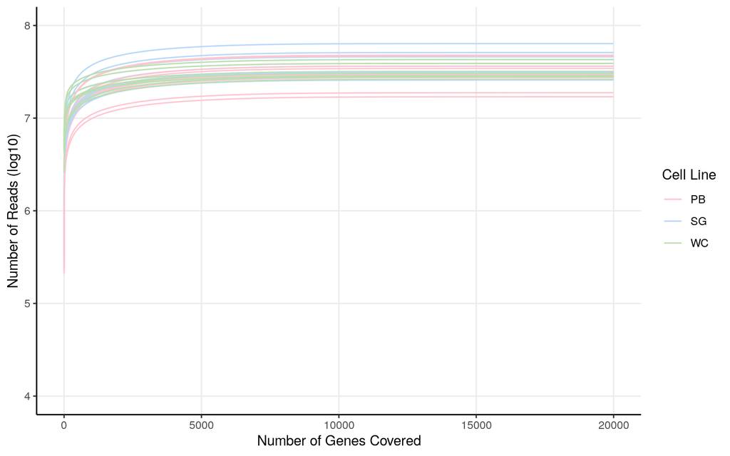

```r
# Define color palette
custom_palette <- qualitative_hcl(3, palette = "Pastel 1")
custom_palette <- sample(custom_palette, 3)

# Use SampleColouring from metadata
SampleColouring <- c("SG", "SG", "PB", "PB", "WC", "WC","SG", "SG", "PB", "PB", "WC", "WC","SG", "SG", "PB", "PB", "WC", "WC","SG", "SG", "PB", "PB", "WC", "WC","SG", "SG", "PB", "PB", "WC", "WC")

# Build cumulative counts
final <- sapply(1:ncol(read.counts), function(i) {
  sort_vals <- read.counts[order(read.counts[, i], decreasing = TRUE), i]
  cumsum(sort_vals)
})
final <- as.data.frame(final)
colnames(final) <- colnames(read.counts)

# Melt and add gene position + sample info
finalmelt <- reshape2::melt(final, variable.name = "Sample")
finalmelt$genes <- rep(1:nrow(final), times = ncol(final))
finalmelt$SampleColouring <- rep(SampleColouring, each = nrow(final))

# Plot cumulative read coverage
ggplot(data = finalmelt, aes(x = genes, y = log10(value), group = Sample, color = SampleColouring)) +
  geom_line() +
  scale_color_manual(values = custom_palette, name = "Cell Line") +
  theme_bw() +
  xlab("Number of Genes Covered") +
  ylab("Number of Reads (log10)") +
  xlim(0, 20000) +
  ylim(4, 8) +
  theme(
    axis.line = element_line(colour = "black"),
    panel.grid.minor = element_blank(),
    panel.border = element_blank(),
    panel.background = element_blank()
  )
```

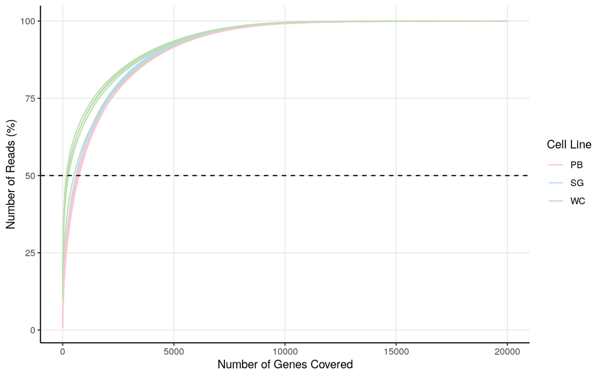

```r
# Create percentage-based plot
orderfinal <- subset(finalmelt, genes == max(finalmelt$genes))
trial <- merge(orderfinal[, c("Sample", "value")], finalmelt, by = "Sample", suffixes = c(".total", ".current"))
trial$percent <- (trial$value.current / trial$value.total) * 100
trial$SampleColouring <- rep(SampleColouring, each = nrow(final))

ggplot(data = trial, aes(x = genes, y = percent, group = Sample, color = SampleColouring)) +
  geom_line() +
  geom_hline(yintercept = 50, linetype = "dashed") +
  scale_color_manual(values = custom_palette, name = "Cell Line") +
  xlab("Number of Genes Covered") +
  ylab("Number of Reads (%)") +
  xlim(0, 20000) +
  theme_bw() +
  theme(
    axis.line = element_line(colour = "black"),
    panel.grid.minor = element_blank(),
    panel.border = element_blank(),
    panel.background = element_blank()
  )
```

As we can see in these plots, even though there is a sample type with lower complexity (Bulk samples), in this case there are no individual sample outliers in terms of complexity or read depth. Excellent!

# Differential Expression Analysis

## Filtration

### *Before Filtration*

Let us begin with the filtration. Personally, I find that its easier to do visually. I am aware that my filtration is more violent than most. Usually, from RNA-Seq experiments, we commonly obtain bi-modal distributions, with the first mode corresponding to lowly expressed genes. I remove these by cutting just before the second mode. This time, I opted to also observe every sample type by itself.

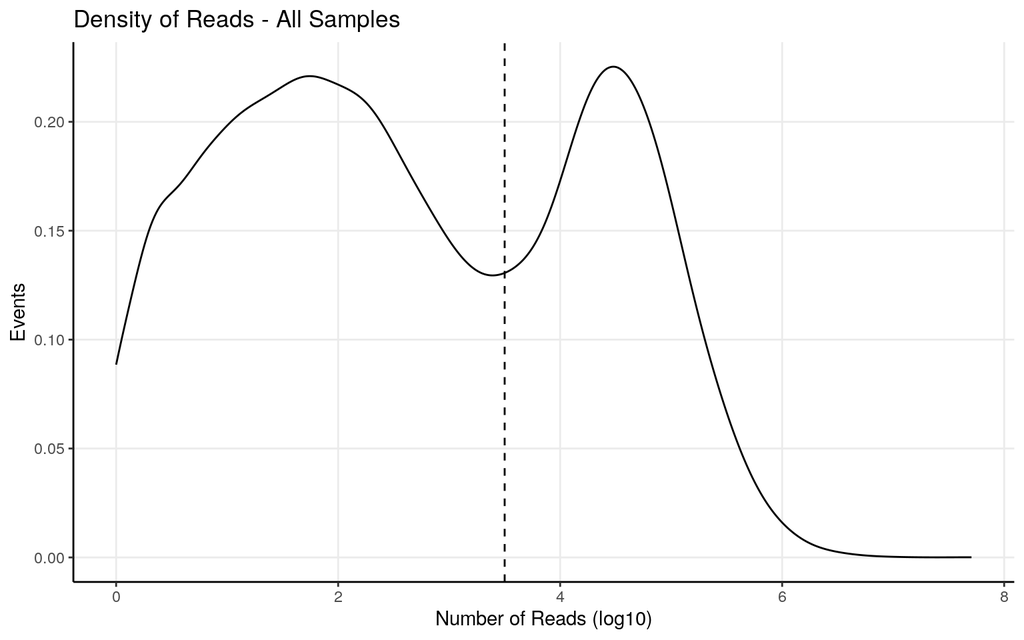

```r
alternew.WC <- log10(rowSums(read.counts[,c(5,6,11,12,17,18,23,24,29,30)]))
alternew.WC <- as.data.frame(alternew.WC)

alternew.BP <- log10(rowSums(read.counts[,c(3,4,9,10,15,16,21,22,27,28)]))
alternew.BP <- as.data.frame(alternew.BP)

alternew.SG <- log10(rowSums(read.counts[,c(1,2,7,8,13,14,19,20,25,26)]))
alternew.SG <- as.data.frame(alternew.SG)

alternew <- log10(rowSums(read.counts))
alternew <- as.data.frame(alternew)

ggplot(alternew, aes(x=alternew)) + geom_density() + theme_bw() + geom_vline(xintercept = 3.5, linetype = "dashed") + ylab("Events") + xlab("Number of Reads (log10)") +
  theme(axis.line = element_line(colour = "black"),
        panel.grid.minor = element_blank(),
        panel.border = element_blank(),
        panel.background = element_blank()) + ggtitle("Density of Reads - All Samples")
```

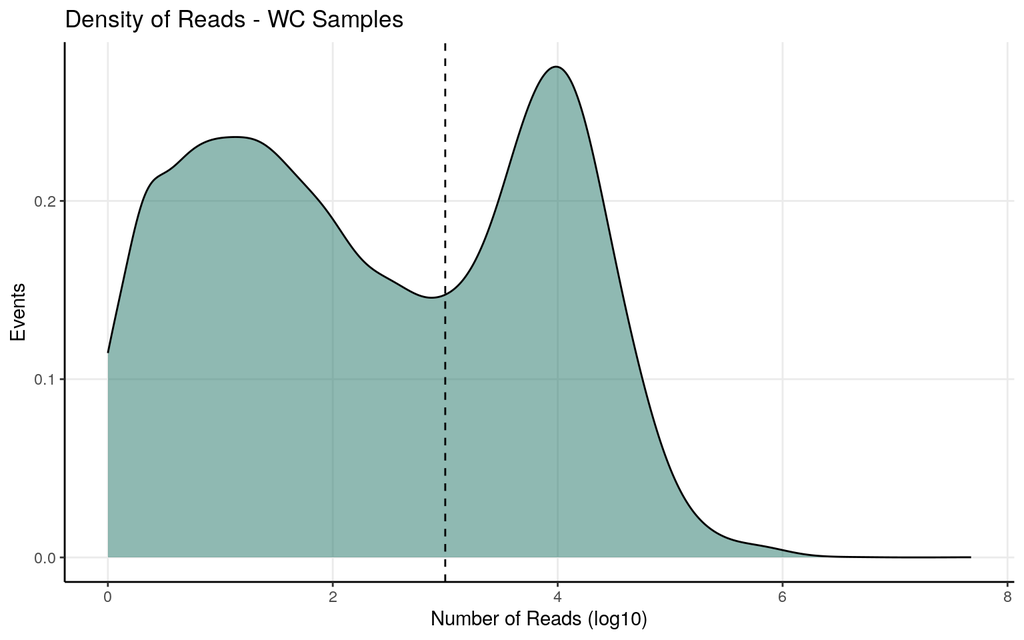

```r
ggplot(alternew.WC, aes(x=alternew.WC)) + geom_density(fill="#207567", alpha=0.5) + theme_bw() + geom_vline(xintercept = 3, linetype = "dashed") + ylab("Events") + xlab("Number of Reads (log10)") +
  theme(axis.line = element_line(colour = "black"),
        panel.grid.minor = element_blank(),
        panel.border = element_blank(),
        panel.background = element_blank()) + ggtitle("Density of Reads - WC Samples")
```

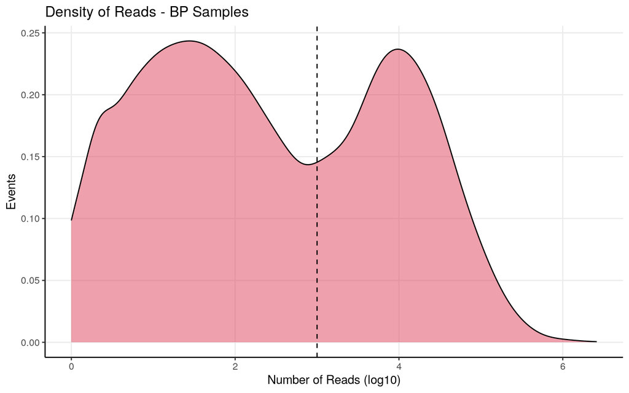

```r
ggplot(alternew.BP, aes(x=alternew.BP)) + geom_density(fill="#de425b", alpha=0.5) + theme_bw() + geom_vline(xintercept = 3, linetype = "dashed") + ylab("Events") + xlab("Number of Reads (log10)") +
  theme(axis.line = element_line(colour = "black"),
        panel.grid.minor = element_blank(),
        panel.border = element_blank(),
        panel.background = element_blank()) + ggtitle("Density of Reads - BP Samples")
```

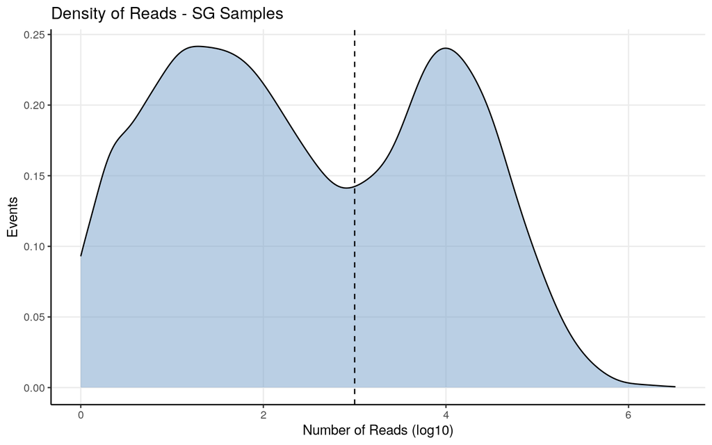

```r
ggplot(alternew.SG, aes(x=alternew.SG)) + geom_density(fill="#769fca", alpha=0.5) + theme_bw() + geom_vline(xintercept = 3, linetype = "dashed") + ylab("Events") + xlab("Number of Reads (log10)") +
  theme(axis.line = element_line(colour = "black"),
        panel.grid.minor = element_blank(),
        panel.border = element_blank(),
        panel.background = element_blank()) + ggtitle("Density of Reads - SG Samples")
```

By seeing the shape of the graph, we can see where we should cut. We have a **binomial distribution** (low reads and noise vs actual biological meaningful reads). The ideal place to cut them is right before the wedge.

### *After Filtration*

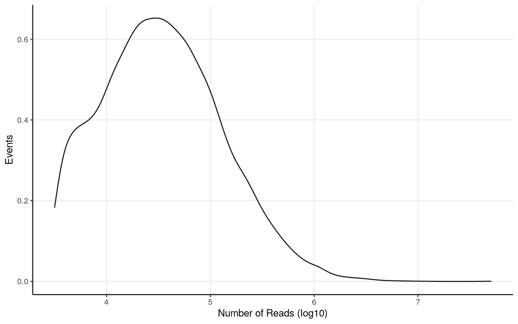

```r
MitoGenes <- fread("~/MitoGenes.txt", header = FALSE)[[1]]

filterednew <- subset(read.counts, alternew>3.5)
filterednew.WC <- subset(read.counts, alternew.WC>3)
filterednew.BP <- subset(read.counts, alternew.BP>3)
filterednew.SG <- subset(read.counts, alternew.SG>3)

#after cutting, its a good idea to visualize again
falternew <- log10(rowSums(filterednew))
falternew <- as.data.frame(falternew)
ggplot(falternew, aes(x=falternew)) + geom_density() + theme_bw() + ylab("Events") + xlab("Number of Reads (log10)") +
  theme(axis.line = element_line(colour = "black"),
        panel.grid.minor = element_blank(),
        panel.border = element_blank(),
        panel.background = element_blank())
```

```r
#lets save the genes which we maintain
impgenes <- row.names(falternew)
impgenes.WC <- c(row.names(filterednew.WC))
impgenes.BP <- c(row.names(filterednew.BP))
impgenes.SG <- c(row.names(filterednew.SG))

#Now we need to select only the rows which have those genes.
finaltable <- read.counts[row.names(read.counts)%in%impgenes,]
finaltable <- finaltable[row.names(finaltable)%in%impgenes.WC,]
finaltable <- finaltable[row.names(finaltable)%in%impgenes.BP,]
finaltable <- finaltable[row.names(finaltable)%in%impgenes.SG,]

write.csv(finaltable, "~/Projects/StressGranules/Simulator/OriginalSamples/SG2023/Filtcounts.txt", row.names = T)
```

## Matrices

Good! Now we can proceed by designing our matrices.

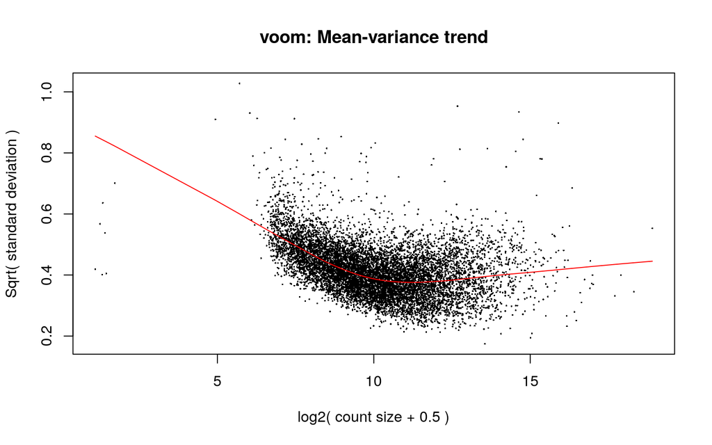

```r
#Let us prepare metadata to add to our samples
forsimple <- c("SG", "SG", "PB", "PB", "WC", "WC","SG", "SG", "PB", "PB", "WC", "WC","SG", "SG", "PB", "PB", "WC", "WC","SG", "SG", "PB", "PB", "WC", "WC","SG", "SG", "PB", "PB", "WC", "WC")


forpatient <- c(rep("1",6),rep("2",6),rep("3",6),rep("4",6),rep("5",6))


metadata <- data.frame(Sample=forsimple, Patient=forpatient)

#To be able to use Voom, we must first convert our read count table into a special DGE object.
D0 <- DGEList(finaltable)


#Then we calculate the normalization factors for these new generated data frames
#Bear in mind this step calculates the normalization factors, but does not normalize itself.
D0 <- calcNormFactors(D0)

#Now we do the matrixes

#the one with thingies by patient
mm <- model.matrix(~0+forpatient+forsimple)


#and now we normalize. This step also turns our counts into log2-counts per million.
y <- voom(D0, mm, plot = T)
```

## Normalisation

For normalisation I convert the read counts into log2CPMs. Its a good way to visualise how the reads are.

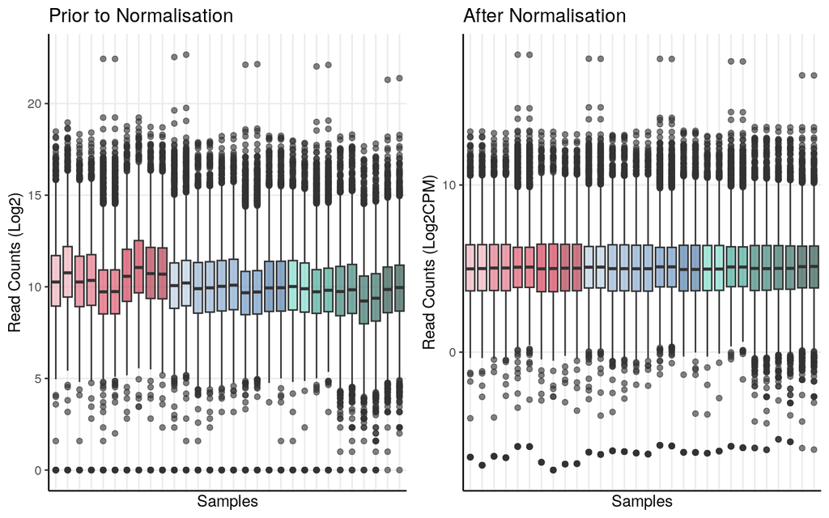

```r
dfforboxy <- finaltable

orderforplots <- c("SG1", "SG1", "SG2", "SG2", "SG3", "SG3","SG4", "SG4", "SG5", "SG5", "PB1", "PB1","PB2", "PB2", "PB3", "PB3", "PB4", "PB4","PB5", "PB5", "WC1", "WC1", "WC2", "WC2","WC3", "WC3", "WC4", "WC4", "WC5", "WC5")
colouring <- data.frame(Sample=colnames(dfforboxy), Types=orderforplots)
dfforboxy <- reshape2::melt(dfforboxy)
colnames(dfforboxy) <- c("Sample", "Expression")
dfforboxy <- merge(dfforboxy, colouring, by="Sample")
prenorm <- ggplot(dfforboxy, aes(x=Sample, y=(log2(Expression+1)), fill=Types)) + geom_boxplot(alpha=0.6) + theme_bw() + ylab("Read Counts (Log2)") + xlab("Samples") + scale_fill_manual(name = "Sample Type", values = c("#B6CBE2", "#89ACD1", "#769FCA", "#5D8DC0", "#3F6FA2", "#F0A8B4", "#E36378", "#DE425B", "#D02541", "#AD1F36", "#6FD8C6", "#2CA08D", "#207567","#1A6054","#124038"), labels=c("SG1", "SG2", "SG3", "SG4", "SG5", "PB1", "PB2", "PB3", "PB4", "PB5", "WC1", "WC2","WC3", "WC4", "WC5")) +
  theme(axis.line = element_line(colour = "black"),
        panel.grid.minor = element_blank(),
        panel.border = element_blank(),
        panel.background = element_blank(),
        axis.text.x=element_blank(),
        axis.ticks.x=element_blank(),
        legend.position = "None") + ggtitle("Prior to Normalisation")

#Using the Standard Matrix

dfforboxy <- y$E
dfforboxy <- reshape2::melt(dfforboxy)
dfforboxy <- dfforboxy[,-1]
colnames(dfforboxy) <- c("Sample", "Expression")
dfforboxy <- merge(dfforboxy, colouring, by="Sample")
postnorm <- ggplot(dfforboxy, aes(x=Sample, y=Expression, fill=Types)) + geom_boxplot(alpha=0.6) + theme_bw() + ylab("Read Counts (Log2CPM)") + xlab("Samples") + scale_fill_manual(name = "Sample Type", values = c("#B6CBE2", "#89ACD1", "#769FCA", "#5D8DC0", "#3F6FA2", "#F0A8B4", "#E36378", "#DE425B", "#D02541", "#AD1F36", "#6FD8C6", "#2CA08D", "#207567","#1A6054","#124038"), labels=c("SG1", "SG2", "SG3", "SG4", "SG5", "PB1", "PB2", "PB3", "PB4", "PB5", "WC1", "WC2","WC3", "WC4", "WC5")) +
  theme(axis.line = element_line(colour = "black"),
        panel.grid.minor = element_blank(),
        panel.border = element_blank(),
        panel.background = element_blank(),
        axis.text.x=element_blank(),
        axis.ticks.x=element_blank(),
        legend.position = "None") + ggtitle("After Normalisation")

ggarrange(prenorm, postnorm, nrow=1)
```

In this case, from the boxplots, we can see that there no samples which can be considered outliers.

## PCA

I like to start with a Principal Component Analysis (PCA), which helps to identify what drives the largest variation in the data.

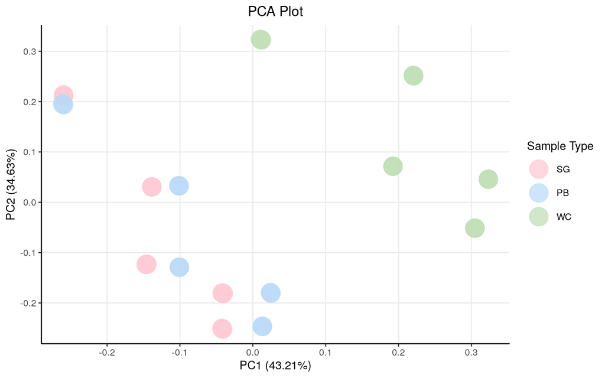

```r
#this is done to be able to do traditional PCA
dfforpca <- y$E
dfforpca <- rbind(dfforpca, SampleColouring)
dfforpca <- t(dfforpca)
numcol <- c(1:(ncol(dfforpca)-1))
dfforpca <- as.data.frame(dfforpca) #for some reason I can only change colum type if its a dataframe

dfforpca[ ,numcol] <- apply(dfforpca[ , numcol], 2,            # to turn our columns into numeric
                            function(x) as.numeric(as.character(x)))

#sapply(dfforpca, class) #to check class

# Or specify the factor levels in the order you want
dfforpca$SampleColouring <- factor(dfforpca$SampleColouring, levels = unique(SampleColouring))

pca_res <- prcomp(dfforpca[,numcol], scale=FALSE) #prepare the pca

#to make everything pretty
p <- autoplot(pca_res, data = dfforpca, x=1, y=2, colour = "SampleColouring", size=8, alpha=0.7)
p <- p + theme_bw() + scale_colour_manual(name = "Sample Type", values = custom_palette, labels=c(unique(SampleColouring)))
p <- p + ggtitle("PCA Plot") + theme(plot.title = element_text(hjust = 0.5)) +
  theme(axis.line = element_line(colour = "black"),
        panel.grid.minor = element_blank(),
        panel.border = element_blank(),
        panel.background = element_blank())
p
```

```r
#in case you want to see them yourself
contribs1 <- pca_res$rotation[,1]
contribs2 <- pca_res$rotation[,2]

#These are the biggest contributors to the PCA1 (right side)
(pos1genes <- sort(contribs1, decreasing=T)[1:10])
```

```
##       IGF2     FGFBP2     RN7SL1    RN7SL4P     RNU4-2       XIST       MT1H
## 0.05971755 0.05237140 0.05148760 0.05110007 0.04896549 0.04660770 0.04601481
##      CCL20     RNU4-1       GNG8
## 0.04584196 0.04511298 0.04361641
```

```r
#These are the biggest contributors to the PCA1 (left side)
(neg1genes <- sort(contribs1, decreasing=F)[1:10])
```

```
##       DDX3Y       USP9Y       KDM5D      RPS4Y1         UTY      EIF1AY
## -0.06329179 -0.05665095 -0.05609531 -0.05587819 -0.05325261 -0.05244090
##         ZFY       IGHG1       WDFY4        MYOF
## -0.04816374 -0.03723072 -0.03352793 -0.03231018
```

```r
#These are the biggest contributors to the PCA2 (up side)
(pos2genes <- sort(contribs2, decreasing=T)[1:10])
```

```
##      DDX3Y     RPS4Y1      USP9Y     EIF1AY      KDM5D        UTY        ZFY
## 0.10732999 0.10239578 0.09974570 0.09767758 0.09674720 0.09369435 0.08875870
##     RN7SL3      IGHG1      AICDA
## 0.06734861 0.06072599 0.05141156
```

```r
#These are the biggest contributors to the PCA2 (down side)
(neg2genes <- sort(contribs2, decreasing=F)[1:10])
```

```
##        XIST        IGF2      FGFBP2      COL5A3      FHIP1A       CCL20
## -0.09227154 -0.05697490 -0.05086834 -0.05081021 -0.04862710 -0.04779409
##       HSPG2     CFAP251      WNT10A       ASCL2
## -0.04664036 -0.04511280 -0.04502222 -0.04337906
```

As one can observe from the PCAs, our PC1 is mostly explained by sample type, with SG closer to PBs. From the PC2 contributors, we can see that we have many sex-specific genes (Y-Chrom genes and XIST), so PC2 is at least partially explained by patient sex, with females on the bottom of the plot.

## Batch Effect Correction

Looking at the PCA I considered that patient origin could be considered a batch effect. I opted to remove this batch effect.

```r
metadata_2 <- metadata
batch_cols <- c("Patient")
metadata_cols <- c("Sample")
mmbatch <- model.matrix(reformulate(paste0("~0 + ",paste0( batch_cols,collapse = " + "))), data=metadata_2)
mmkeep <- model.matrix(reformulate(paste0("~0 + ",paste0( metadata_cols,collapse =  "+" ))), data=metadata_2)
mm <- cbind(mmkeep,mmbatch)
D0 <- DGEList(2^y$E) #senescence_normcounts
D0 <- calcNormFactors(D0)
y <- voom(D0, mm, plot = F)
```

```
## Coefficients not estimable: Patient5
```

```r
fit <- lmFit(y, mm)
```

```
## Coefficients not estimable: Patient5
```

```
## Coefficients not estimable: Patient5
```

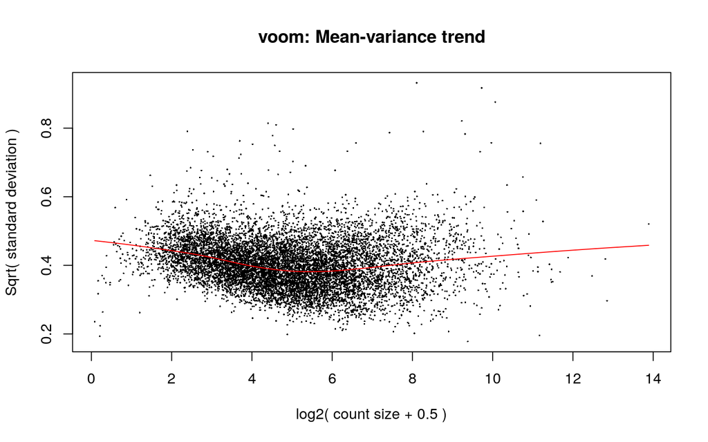

```r
beta <- fit$coefficients[,-(1:ncol(mmkeep)),drop=FALSE]
#beta <- fit$coefficients
beta[is.na(beta)] <- 0
corrcounts_v1 <- as.matrix(y$E) - beta %*% t(mmbatch)
offset <- apply(corrcounts_v1,1,min) - apply(y$E,1,min)
corrcounts_v1 <- as.data.frame(corrcounts_v1-offset)
corrcounts_v1 <- 2^corrcounts_v1
y <- voom(corrcounts_v1, mm, plot = T)
```

## Batch Corrected PCA

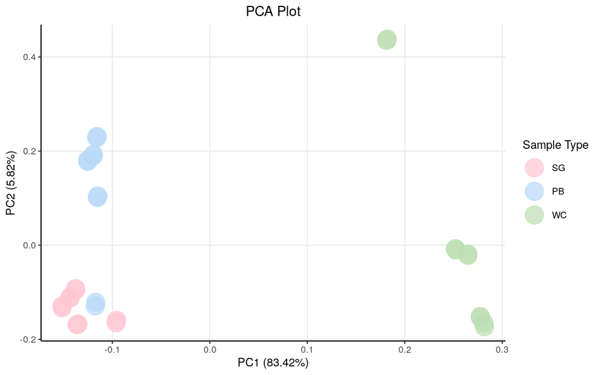

```r
#this is done to be able to do traditional PCA
dfforpca <- y$E
dfforpca <- rbind(dfforpca, SampleColouring)
dfforpca <- t(dfforpca)
numcol <- c(1:(ncol(dfforpca)-1))
dfforpca <- as.data.frame(dfforpca) #for some reason I can only change colum type if its a dataframe

dfforpca[ ,numcol] <- apply(dfforpca[ , numcol], 2,            # to turn our columns into numeric
                            function(x) as.numeric(as.character(x)))

#sapply(dfforpca, class) #to check class

# Or specify the factor levels in the order you want
dfforpca$SampleColouring <- factor(dfforpca$SampleColouring, levels = unique(SampleColouring))

pca_res <- prcomp(dfforpca[,numcol], scale=FALSE) #prepare the pca

#to make everything pretty
p <- autoplot(pca_res, data = dfforpca, x=1, y=2, colour = "SampleColouring", size=8, alpha=0.7)
p <- p + theme_bw() + scale_colour_manual(name = "Sample Type", values = custom_palette, labels=c(unique(SampleColouring)))
p <- p + ggtitle("PCA Plot") + theme(plot.title = element_text(hjust = 0.5)) +
  theme(axis.line = element_line(colour = "black"),
        panel.grid.minor = element_blank(),
        panel.border = element_blank(),
        panel.background = element_blank())
p
```

```r
#in case you want to see them yourself
contribs1 <- pca_res$rotation[,1]
contribs2 <- pca_res$rotation[,2]

#These are the biggest contributors to the PCA1 (right side)
(pos1genes <- sort(contribs1, decreasing=T)[1:10])
```

```
##     RN7SL3     RN7SL1    RN7SL4P     RNU4-2     RNU4-1      RPL39    MT-RNR2
## 0.05942624 0.05896225 0.05193490 0.04664277 0.04270045 0.03720699 0.03651375
##      RPS12      RPS21      RPL12
## 0.03551700 0.03406736 0.03375562
```

```r
#These are the biggest contributors to the PCA1 (left side)
(neg1genes <- sort(contribs1, decreasing=F)[1:10])
```

```
##       SYNE2        FLNA      IQGAP1         TTN       MYH10       MACF1
## -0.03184750 -0.03131897 -0.03105649 -0.02978856 -0.02945860 -0.02930389
##        MDN1     DYNC1H1      MYCBP2        FLNB
## -0.02898478 -0.02869992 -0.02810949 -0.02792254
```

```r
#These are the biggest contributors to the PCA2 (up side)
(pos2genes <- sort(contribs2, decreasing=T)[1:10])
```

```
##    SLC16A7      ALG10   TMEM106B     ALG10B      CD164      MANEA     SCAMP1
## 0.04121660 0.03875730 0.03741520 0.03717528 0.03634805 0.03476889 0.03379899
##      TMED5      MBNL3     LMBRD2
## 0.03357626 0.03299791 0.03276096
```

```r
#These are the biggest contributors to the PCA2 (down side)
(neg2genes <- sort(contribs2, decreasing=F)[1:10])
```

```
##     SNORD3A      MT-ND3        PLEC      MT-CO3        SMTN    MTATP6P1
## -0.04687940 -0.04276184 -0.03576056 -0.03532320 -0.03263171 -0.03161287
##       OBSCN        MYH9      MT-ND5     MT-ATP6
## -0.03121542 -0.03011402 -0.02994890 -0.02950810
```

Good, now we have less variance attributed to patient of origin.

## Linear Models

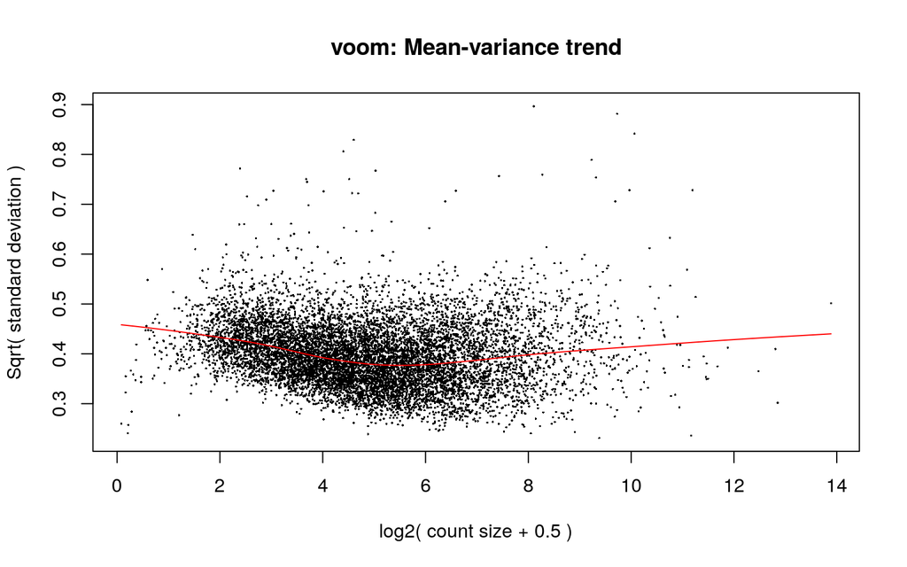

```r
mm <- model.matrix(~0+forsimple)

#and now we normalize. This step also turns our counts into log2-counts per million.
y <- voom(corrcounts_v1, mm, plot = T)
```

```r
fitted <- lmFit(y,mm)


#Just to see if everything is ok
head(coef(fitted))
```

```
##       forsimplePB forsimpleSG forsimpleWC
## AAAS     5.581054    5.739849    5.063773
## AACS     4.565285    4.714308    4.009534
## AAGAB    5.496050    5.487226    5.398009
## AAK1     8.730261    8.524384    7.359994
## AAMP     6.976582    7.040167    6.252344
## AAR2     5.511844    5.631855    4.991394
```

```r
#Lets do the comparisons
#without pbs
SG.vs.WC <- makeContrasts(forsimpleSG  - forsimpleWC, levels = colnames(coef(fitted)))
SG.vs.PB <- makeContrasts(forsimpleSG  - forsimplePB, levels = colnames(coef(fitted)))
#if more is necessary, add more


#Lets fit the contrasts
tmp_SG.vs.WC <- contrasts.fit(fitted, SG.vs.WC)
tmp_SG.vs.PB <- contrasts.fit(fitted, SG.vs.PB)

#Correction for multiple testing
tmp_SG.vs.WC <- eBayes(tmp_SG.vs.WC)
tmp_SG.vs.PB <- eBayes(tmp_SG.vs.PB)
```

Lets move on to the main analyses.

```r
#TOP Tables
top_SG.vs.WC <- topTable(tmp_SG.vs.WC, sort.by = "logFC", n=Inf)
top_SG.vs.PB <- topTable(tmp_SG.vs.PB, sort.by = "logFC", n=Inf)

#DEGenes
DEGenes_SG.vs.WC <- top_SG.vs.WC
DEGenes_SG.vs.PB <- top_SG.vs.PB
```

# SG vs Whole-Cell Transcriptome

## Volcano Plot

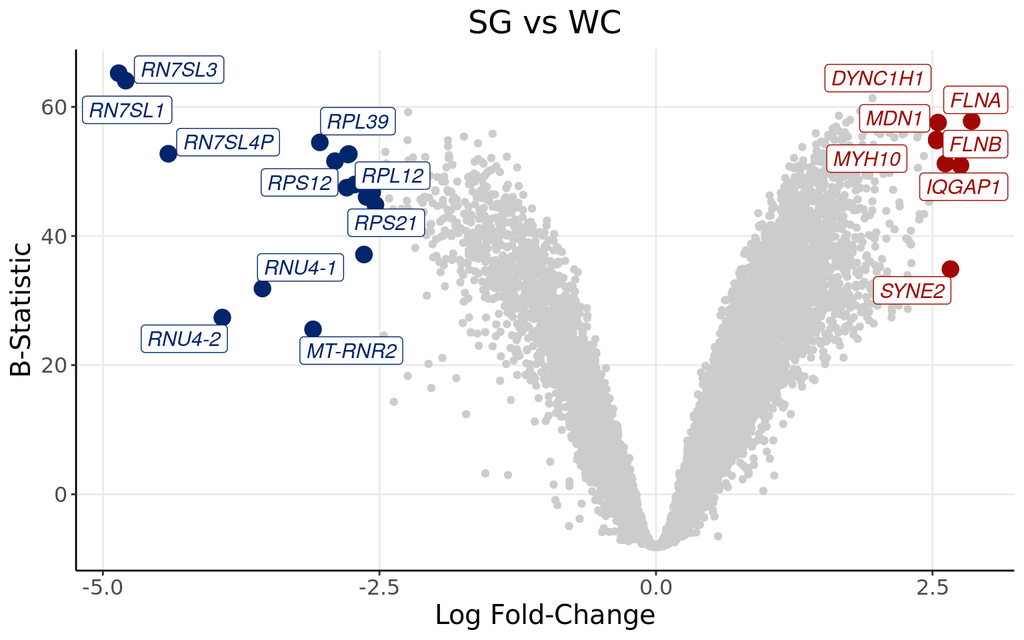

```r
write.table(x = DEGenes_SG.vs.WC,
          file = "~/Projects/StressGranules/SGPAPER/SGvsWC/TcellSG.txt", sep="\t", col.names = TRUE, row.names = TRUE, quote=FALSE)

ndegs <- 10
upmarkers <- as.data.frame(DEGenes_SG.vs.WC[DEGenes_SG.vs.WC$logFC>2.5 & DEGenes_SG.vs.WC$adj.P.Val<0.05,] )
downmarkers <- as.data.frame(DEGenes_SG.vs.WC[DEGenes_SG.vs.WC$logFC< -2.5 & DEGenes_SG.vs.WC$adj.P.Val<0.05,] )

ggplot(data=DEGenes_SG.vs.WC,
                 aes(x=logFC,
                     y=  B)) +
  geom_point(color="#CCCCCC")+
  theme_bw() + ylab("B-Statistic")+xlab("Log Fold-Change")+
  theme(axis.line = element_line(colour = "black"),
        panel.grid.minor = element_blank(),
        panel.border = element_blank(),
        panel.background = element_blank()) +
  ggtitle("SG vs WC")+
  theme(plot.title = element_text(hjust = 0.5), plot.subtitle = element_text(hjust = 0.5)) +
  geom_point(data=upmarkers, aes(x=logFC, y=  B), color="#A10702",size=4)+
  geom_point(data=downmarkers, aes(x=logFC, y=  B), color="#03256C",size=4)+
  geom_label_repel(upmarkers[1:ndegs,] , mapping=aes(label=row.names(upmarkers)[1:ndegs]),size=4,point.padding=-0.5, color="#A10702",max.overlaps = 20, fontface="italic")+
  geom_label_repel(downmarkers[1:ndegs,] , mapping=aes(label=row.names(downmarkers)[1:ndegs]),size=4,point.padding=-0.5, color="#03256C",max.overlaps = 20, fontface="italic")+
  theme(text=element_text(size=15,  family="Arial MS"))
```

## Volcano Plot with Gene Length

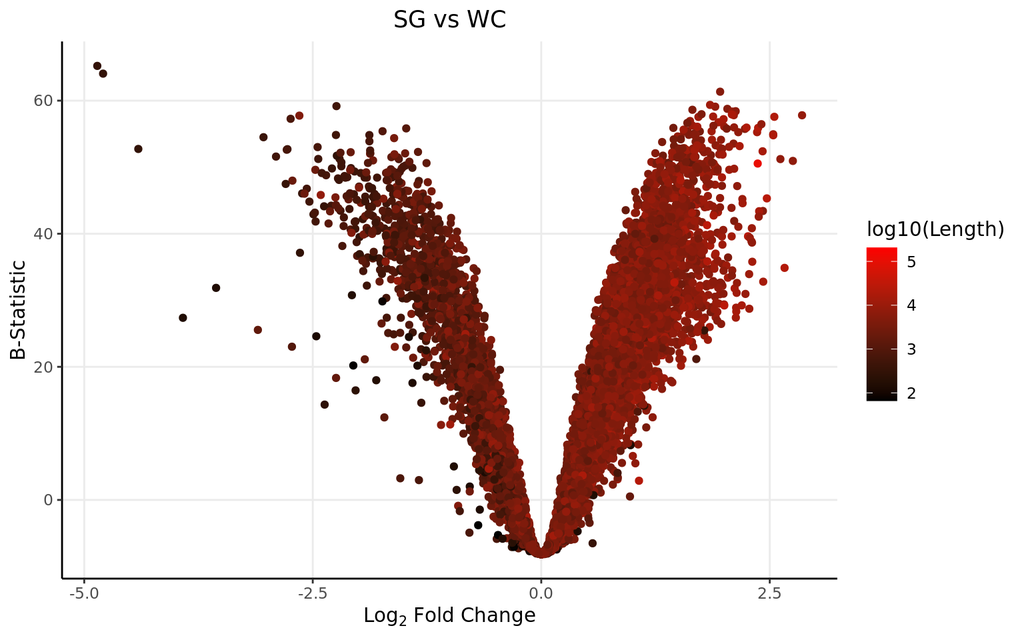

```r
DEGenes_SG.vs.WC$Gene <- row.names(DEGenes_SG.vs.WC)
colnames(genelength) <- c("Length","Gene")
DEGenes_SG.vs.WC <- merge(DEGenes_SG.vs.WC, genelength, by="Gene")

ggplot(data=DEGenes_SG.vs.WC,
                 aes(x=logFC,
                     y=  B)) +
  geom_point(aes(color=log10(Length)))+
  theme_bw() +
  theme(axis.line = element_line(colour = "black"),
        panel.grid.minor = element_blank(),
        panel.border = element_blank(),
        panel.background = element_blank()) +
  ggtitle("SG vs WC")+ xlab(expression(Log[2] ~ Fold ~ Change)) + ylab("B-Statistic") +
  theme(plot.title = element_text(hjust = 0.5))  +
  scale_colour_gradient(low = "black", high = "red")+ theme(text=element_text(family = "Quicksand"))
```

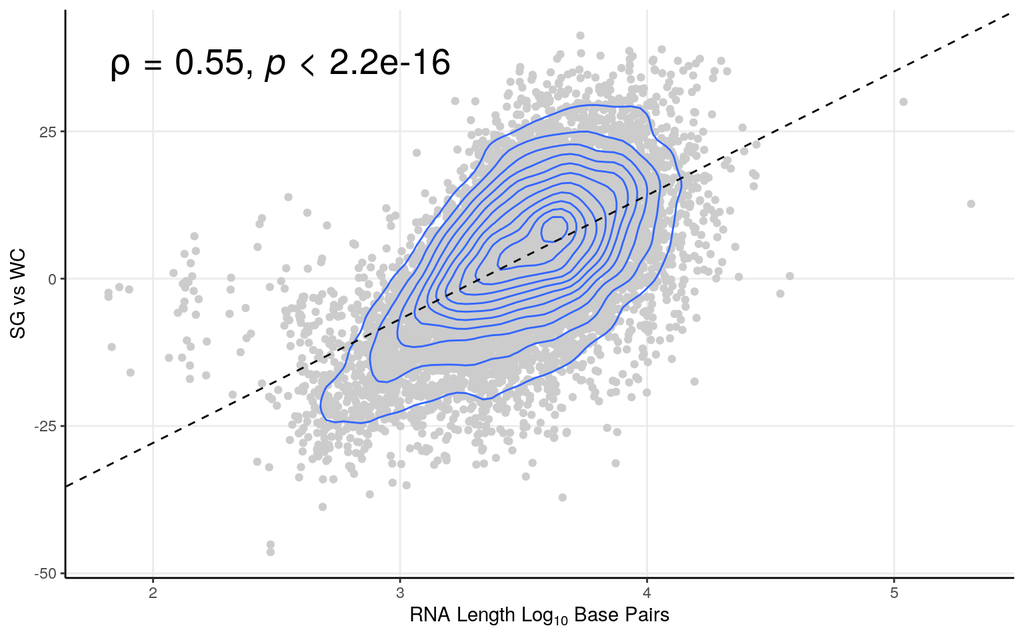

```r
smooth.SG <- lm(t~log10(Length), DEGenes_SG.vs.WC)
liner.SG <- rstandard(smooth.SG)
DEGenes_SG.vs.WC <-cbind(DEGenes_SG.vs.WC, liner.SG)
colnames(DEGenes_SG.vs.WC)[9] <- "Residuals"
row.names(DEGenes_SG.vs.WC) <- DEGenes_SG.vs.WC$Gene
linemarkers <- as.data.frame(DEGenes_SG.vs.WC[abs(DEGenes_SG.vs.WC$Residuals)>4,])

# Calculate the Spearman correlation coefficient
spearman_corr <- cor(DEGenes_SG.vs.WC$t, log10(DEGenes_SG.vs.WC$Length), method = "spearman")



ggplot(DEGenes_SG.vs.WC, aes(y=t, x=log10(Length))) + geom_point(color="#CCCCCC", alpha=1) +   theme_bw()+ geom_density_2d()+
 ylab("SG vs WC") + xlab(expression(RNA ~ Length ~ Log[10] ~ Base ~ Pairs)) +
  theme(axis.line = element_line(colour = "black"),
        panel.grid.minor = element_blank(),
        panel.border = element_blank(),
        panel.background = element_blank()) +
  theme(plot.title = element_text(hjust = 0.5))  +
  geom_abline(slope=smooth.SG$coefficients[2], intercept = smooth.SG$coefficients[1], linetype = "dashed")+ stat_cor(method = "spearman", cor.coef.name = "rho",size=7)
```

As expected from a DC study, we see a lenght bias towards longer transcripts.

## Expression Graphs (Extra QC)

As an added control, lets plot these genes in regard to their expression. This helps to see if the expression differences are robust, and not just driven by one sample.

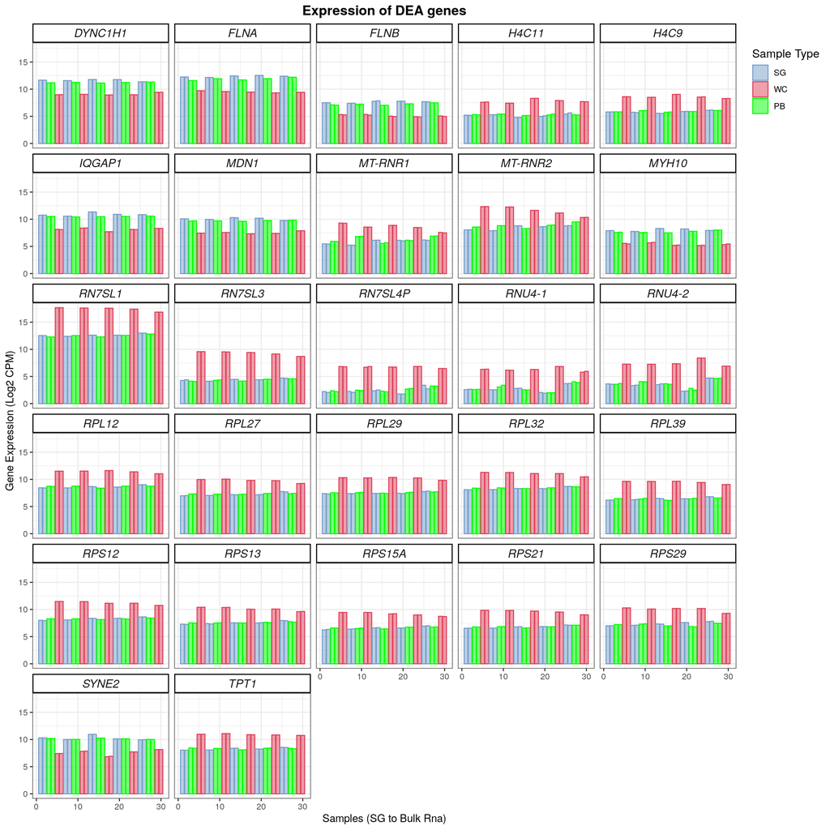

```r
upmarkers <- as.data.frame(DEGenes_SG.vs.WC[DEGenes_SG.vs.WC$logFC>2.5 & DEGenes_SG.vs.WC$adj.P.Val<0.05,] )
downmarkers <- as.data.frame(DEGenes_SG.vs.WC[DEGenes_SG.vs.WC$logFC< -2.5 & DEGenes_SG.vs.WC$adj.P.Val<0.05,] )

finagenes <- rbind(upmarkers, downmarkers)

dfforexpression <- dfforpca
samplecodes <- data.frame(samples=row.names(dfforexpression), purity=c(1:30))
sampletype <- data.frame(samples=row.names(dfforexpression), sampletype=forsimple)
dfforexpression <- t(dfforexpression)
genesforexp <- dfforexpression[row.names(dfforexpression)%in%row.names(finagenes),]
genesforexp <- reshape2::melt(genesforexp)
colnames(genesforexp) <- c("Gene", "samples", "expression")
genesforexp <- merge(genesforexp, samplecodes, by="samples")
genesforexp <- merge(genesforexp, sampletype, by="samples")
genesforexp <- genesforexp[,-1]
genesforexp[,2] <- as.numeric(genesforexp[,2])
genesforexp[,1] <- as.character(genesforexp[,1])
genesforexp <- genesforexp[order(genesforexp$Gene),]


winnyplot <- ggplot(genesforexp, aes(x=purity, y=expression, fill=sampletype, colour=sampletype)) + geom_bar(position="dodge", stat="identity", alpha=0.5) + facet_wrap(.~ Gene, ncol=5)
winnyplot <- winnyplot + scale_fill_manual(name = "Sample Type", values = c("#769fca", "#de425b", "green"), breaks = c("SG", "WC", "PB")) + scale_colour_manual(name = "Sample Type", values = c("#769fca", "#de425b", "green"), breaks = c("SG", "WC", "PB"))
winnyplot <- winnyplot + theme_bw() + xlab("Samples (SG to Bulk Rna)") + ylab("Gene Expression (Log2 CPM)") + theme(
      strip.text.x = element_text(
        size = 12, face="italic"
        )) +
 theme(
   strip.background = element_rect(
     color="black", fill="#FFFFFF", size=1, linetype="solid"
     )
   ) + theme(
    #legend.position = c(.95, .40),
    legend.justification = c("right", "top"),
    legend.box.just = "right",
    ) + theme(legend.title = element_text(size = 12)) + ggtitle("Expression of DEA genes") + theme(plot.title = element_text(hjust = 0.5, size=14, face="bold"))
winnyplot
```

## GSEA Enrichment

Now that we have our genes of interest, it would also be interesting to see what are the **altered gene sets** between upregulated and downregulated transcripts from the above comparison. Therefore, lets perform a *Gene Set Enrichment Analysis*

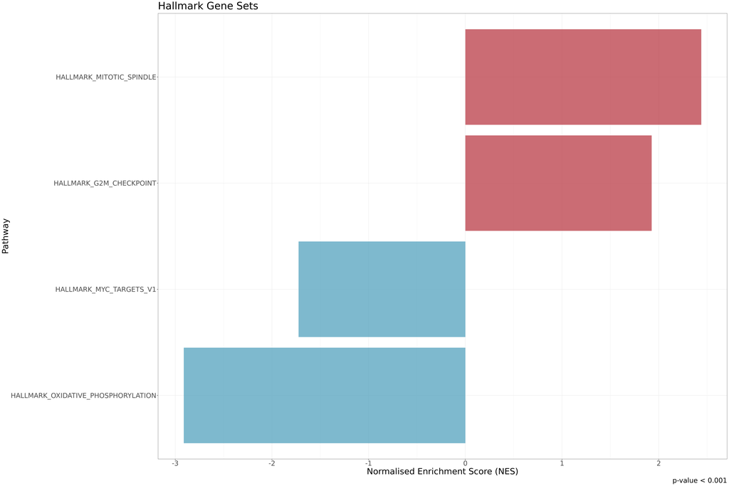

```r
#for all genes
DEGenes_SG.vs.WC <- DEGenes_SG.vs.WC[order(DEGenes_SG.vs.WC[,4]),]
gseatool <- DEGenes_SG.vs.WC[,4]
gseatool <- as.data.frame(gseatool)
colnames(gseatool)[1] <- "t"
gseatool[,2] <- DEGenes_SG.vs.WC$Gene
colnames(gseatool)[2] <- "Symbol"
gseatool <- gseatool[,c(2,1)]

vectorranks <- gseatool$t
names(vectorranks) <- gseatool$Symbol


#to load our pathways
hallmarks.gs <- msigdbr(species = "Homo sapiens", collection =  "H")

hallmarks.gsets <- hallmarks.gs %>% split(x = .$gene_symbol, f = .$gs_name)

for (set in names(hallmarks.gsets)){
  hallmarks.gsets[[set]] <- toupper(hallmarks.gsets[[set]])
}

hallmarks.res <- fgsea(pathways = hallmarks.gsets,
                       stats = vectorranks)

hallmarks.res.tidy <- hallmarks.res %>%
  as_tibble() %>%
  arrange(desc(NES))

hallmarks.res.tidy %>%
  dplyr::select(-leadingEdge, -ES) %>%
  arrange(padj)

hallmark.sg.t <- hallmarks.res.tidy[,c(1,3,6)]
hallmark.sg.t <- as.data.frame(hallmark.sg.t)

#this small part is generic
thresh <- 0.001

#this one is no longer generic
data_to_plot <- hallmarks.res.tidy %>% filter(padj < thresh)

statvec <- c()
for (i in 1:nrow(data_to_plot)){
  if (data_to_plot[i,6] > 0){
    status <- "Upregulated"
  }
 else {
   status <- "Downregulated"
 }
statvec <- c(statvec, status)
}

data_to_plot$Status <- statvec

##-----HALMARK-----
gsea_plot_hall <- ggplot(data_to_plot, aes(reorder(pathway, NES), NES)) +
  geom_col(aes(fill= Status), alpha=0.75) + scale_fill_manual(values = c("#53A2BE","#BA3B46"), name = "Regulation Status", labels = c("Downregulated", "Upregulated"), breaks = c("Downregulated", "Upregulated")) +
  coord_flip() +
  labs(x="Pathway", y="Normalised Enrichment Score (NES)",
       title= "Hallmark Gene Sets",
       caption = paste0("p-value < ", thresh)) + theme(plot.title = element_text(hjust = 1)) +
  theme_bw() + theme(text=element_text(family = "Quicksand")) + theme(legend.position = "none")


gsea_plot_hall+
  theme(text=element_text(size=25,  family="Arial MS"))
```

## GSEA Length

Now, since SGs are enriched for longer transcripts, these pathways may simply be the ones which are tipically enriched in longer transcripts. Therefore, I will repeat the analysis, but using transcript lenght instead of t-statistic.

```r
#for all genes
DEGenes_SG.vs.WC <- DEGenes_SG.vs.WC[order(DEGenes_SG.vs.WC[,8]),]
gseatool <- DEGenes_SG.vs.WC[,8]
gseatool <- as.data.frame(gseatool)
colnames(gseatool)[1] <- "t"
gseatool[,2] <- DEGenes_SG.vs.WC$Gene
colnames(gseatool)[2] <- "Symbol"
gseatool <- gseatool[,c(2,1)]

#for only the genes without the contamination


vectorranks <- log10(gseatool$t)
vectorranks <- scale(vectorranks)
names(vectorranks) <- gseatool$Symbol


#to load our pathways

##-----HALLMARK-----
hallmarks.gs <- msigdbr(species = "Homo sapiens", collection = "H")

hallmarks.gsets <- hallmarks.gs %>% split(x = .$gene_symbol, f = .$gs_name)

for (set in names(hallmarks.gsets)){
  hallmarks.gsets[[set]] <- toupper(hallmarks.gsets[[set]])
}

hallmarks.res <- fgsea(pathways = hallmarks.gsets,
                       stats = vectorranks)
```

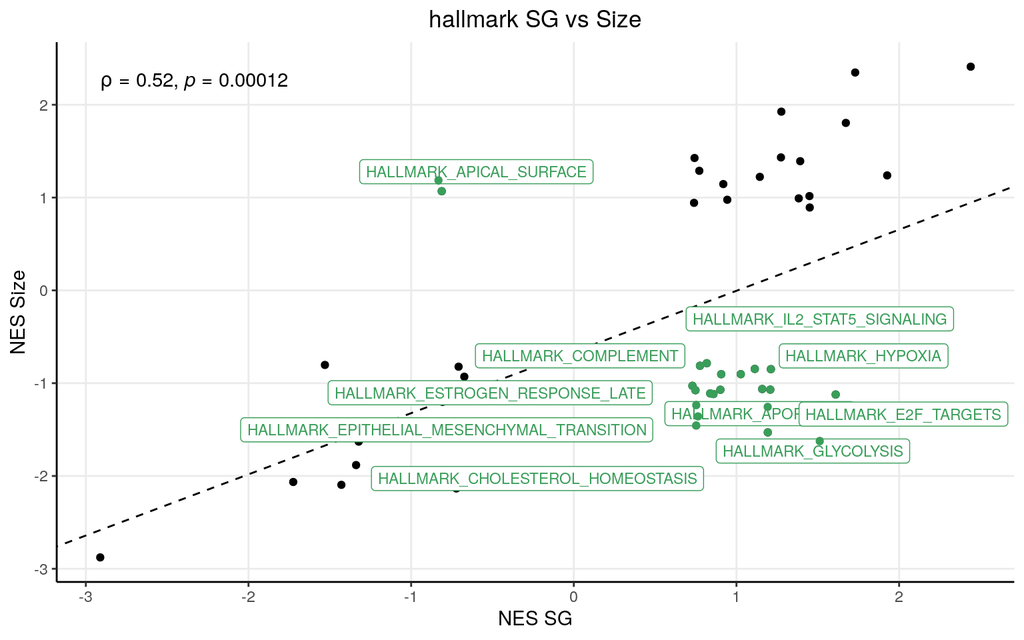

```r
hallmarks.res.tidy <- hallmarks.res %>%
  as_tibble() %>%
  arrange(desc(NES))

hallmarks.res.tidy %>%
  dplyr::select(-leadingEdge, -ES) %>%
  arrange(padj)

hallmark.size.t <- hallmarks.res.tidy[,c(1,3,6)]
hallmark.size.t <- as.data.frame(hallmark.size.t)


#HALLMARK
hallmark.scatter_ak <- merge(hallmark.sg.t, hallmark.size.t, by="pathway")
colnames(hallmark.scatter_ak) <- c("pathway", "sg_pval", "sg", "size_pval", "size")
hallmark.scatter_ak <- na.omit(hallmark.scatter_ak)
res_hallmark <- lm(size ~ sg, hallmark.scatter_ak)

vip.pathways_ak <- as.data.frame(hallmark.scatter_ak[(hallmark.scatter_ak$sg/hallmark.scatter_ak$size)<0,] )



ggplot(hallmark.scatter_ak, aes(x=sg, y=size)) + geom_point(color="black", alpha=01) +   theme_bw()+
 xlab("NES SG") + ylab("NES Size") +
  theme(axis.line = element_line(colour = "black"),
        panel.grid.minor = element_blank(),
        panel.border = element_blank(),
        panel.background = element_blank()) + ggtitle("hallmark SG vs Size")+
  theme(plot.title = element_text(hjust = 0.5)) +
  geom_abline(slope=res_hallmark$coefficients[2], intercept = res_hallmark$coefficients[1], linetype = "dashed") +
  geom_label_repel(vip.pathways_ak[1:ndegs,] , mapping=aes(label=vip.pathways_ak$pathway[1:ndegs]),size=3,point.padding=-0.5, color="#399e5a",max.overlaps = 200)+
  geom_point(data=vip.pathways_ak, aes(x=sg, y= size), color="#399e5a") + stat_cor(method = "spearman", cor.coef.name = "rho")
```

Barring some exceptions which I labeled on the plot, most gene set enrichment is driven by transcript size.

## Most altered pathways

I opted to see altered pathways as a whole. That is, ignoring bidirectionally and simply looking at what pathways are more altered as a whole (i.e, more expressed genes on either side).

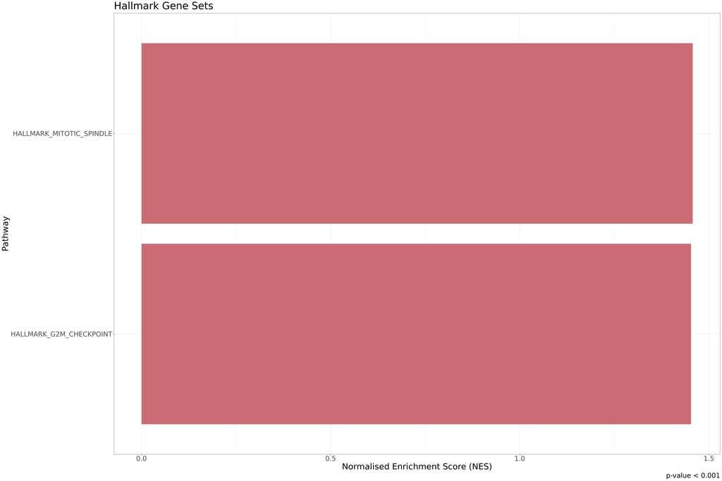

# SG vs PB

## Volcano Plot

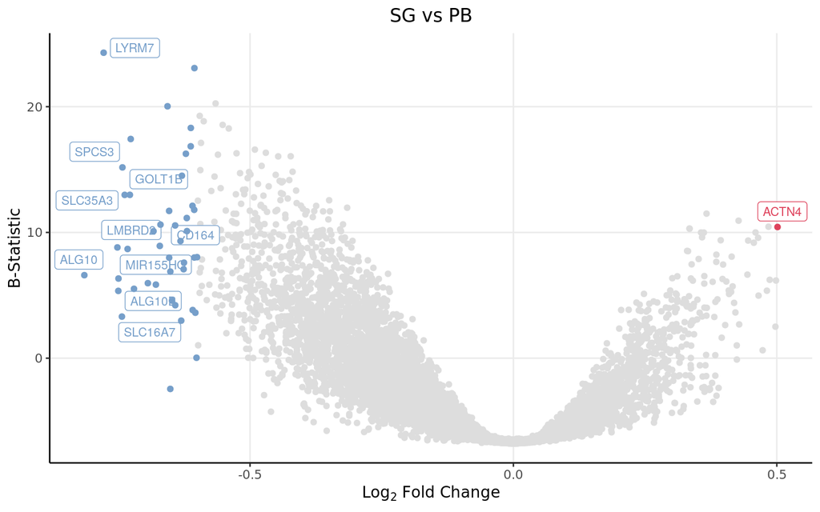

```r
write.table(x = DEGenes_SG.vs.PB,
          file = "~/Projects/StressGranules/SGPAPER/RealSGs/TcellPB.txt", sep="\t", col.names = TRUE, row.names = TRUE, quote=FALSE)


ndegs <- 10
upmarkers <- as.data.frame(DEGenes_SG.vs.PB[DEGenes_SG.vs.PB$logFC>0.5 & DEGenes_SG.vs.PB$adj.P.Val<0.05,] )
downmarkers <- as.data.frame(DEGenes_SG.vs.PB[DEGenes_SG.vs.PB$logFC< -0.6 & DEGenes_SG.vs.PB$adj.P.Val<0.05,] )


ggplot(data=DEGenes_SG.vs.PB,
                 aes(x=logFC,
                     y=  B)) +
  geom_point(color="#DDDDDD")+
  theme_bw() +
  theme(axis.line = element_line(colour = "black"),
        panel.grid.minor = element_blank(),
        panel.border = element_blank(),
        panel.background = element_blank()) +
  ggtitle("SG vs PB")+
  theme(plot.title = element_text(hjust = 0.5)) +
  geom_label_repel(upmarkers[1:ndegs,] , mapping=aes(label=row.names(upmarkers)[1:ndegs]),size=3,point.padding=-0.5, color="#de425b",max.overlaps = 200)+
  geom_label_repel(downmarkers[1:ndegs,] , mapping=aes(label=row.names(downmarkers)[1:ndegs]),size=3,point.padding=-0.5, color="#769fca",max.overlaps = 200)+
  geom_point(data=upmarkers, aes(x=logFC, y=  B), color="#de425b")+
  geom_point(data=downmarkers, aes(x=logFC, y=  B), color="#769fca") + xlab(expression(Log[2] ~ Fold ~ Change)) + ylab("B-Statistic") + theme(text=element_text(family = "Quicksand"))
```

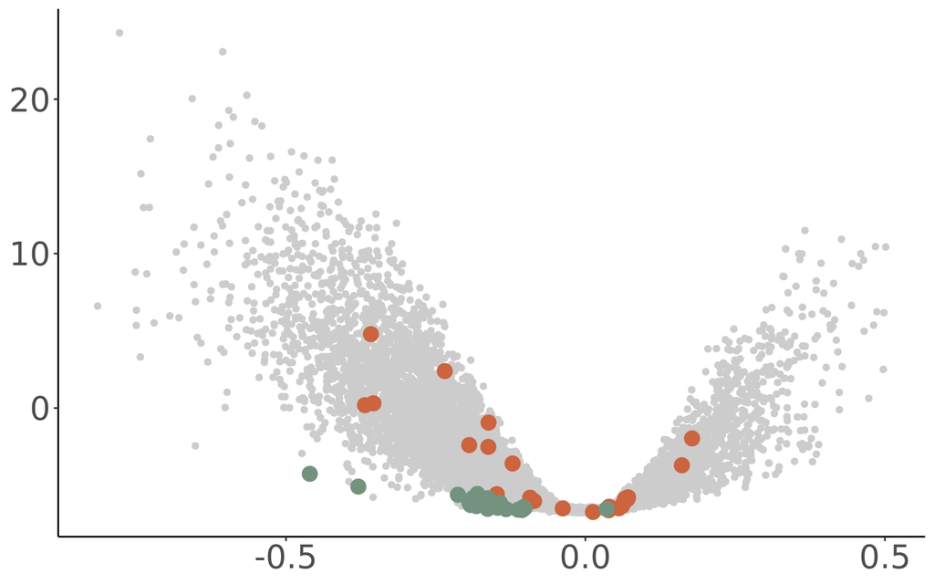

```r
#tcell_t <- data.frame(Gene=row.names(DEGenes_WC.vs.SG), stcell_t=DEGenes_WC.vs.SG$t, stcell_logFC=DEGenes_WC.vs.SG$logFC)

DEGenes <- DEGenes_SG.vs.PB

MitoGenes <- fread("~/MitoGenes.txt")[[1]]
MitoData <- DEGenes[rownames(DEGenes) %in% MitoGenes, ]
NucGenes <- fread("~/rnalocate_mito_filt.csv")[[1]]
NucData <- DEGenes[rownames(DEGenes) %in% NucGenes, ]
(m <- ggplot(data=DEGenes,
                 aes(x=logFC,
                     y=B)) +
  geom_point(color="#CCCCCC") +
  geom_point(data=NucData, aes(x=logFC, y=B), color="#CB643F", size=4) +
  geom_point(data=MitoData, aes(x=logFC, y=B), color="#73937E", size=4) +
  ylab("B-Statistic") +
  xlab(expression(Log[2]~"Fold-Change")) +
  theme(
    axis.line = element_line(colour = "black"),
    panel.grid.major = element_blank(),   # remove major gridlines
    panel.grid.minor = element_blank(),   # remove minor gridlines
    panel.border = element_blank(),
    panel.background = element_blank(),
    axis.title = element_blank()
  ) +
  theme(plot.title = element_text(hjust = 0.5), plot.subtitle = element_text(hjust = 0.5)) +
  theme(text=element_text(size=25, family="Arial MS")))
```

```r
png("~/Projects/StressGranules/SGPAPER/Images/PNG/CurdyMito.png", width = 7, height=6, units = "in", res=300)
m
dev.off()
```

The differences are very small.

# MA Plot

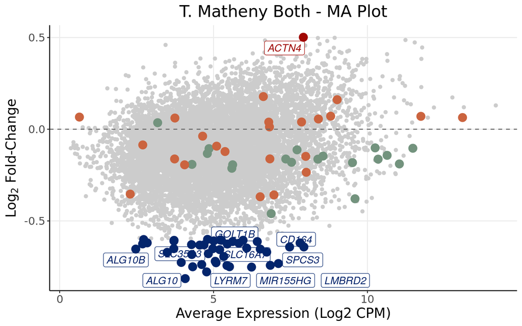

```r
# MA plot: mean expression (x) vs logFC (y), same highlighting scheme as the volcano

ggplot(data=DEGenes,
                 aes(x=AveExpr,
                     y=logFC)) +
  geom_point(color="#CCCCCC") +
  geom_point(data=MitoData, aes(x=AveExpr, y=logFC), color="#73937E", size=4) +
  geom_point(data=NucData, aes(x=AveExpr, y=logFC), color="#CB643F", size=4) +
  geom_hline(yintercept = 0, linetype="dashed", color="grey40") +
  theme_bw() + ylab(expression(Log[2]~"Fold-Change")) + xlab("Average Expression (Log2 CPM)") +
  theme(axis.line = element_line(colour = "black"),
        panel.grid.minor = element_blank(),
        panel.border = element_blank(),
        panel.background = element_blank()) +
  ggtitle("T. Matheny Both - MA Plot") +
  theme(plot.title = element_text(hjust = 0.5), plot.subtitle = element_text(hjust = 0.5)) +
  geom_label_repel(upmarkers[1:ndegs,], mapping=aes(x=AveExpr, y=logFC, label=row.names(upmarkers)[1:ndegs]), size=4, point.padding=-0.5, color="#A10702", max.overlaps=20, fontface="italic") +
  geom_label_repel(downmarkers[1:ndegs,], mapping=aes(x=AveExpr, y=logFC, label=row.names(downmarkers)[1:ndegs]), size=4, point.padding=-0.5, color="#03256C", max.overlaps=20, fontface="italic") +
  geom_point(data=upmarkers, aes(x=AveExpr, y=logFC), color="#A10702", size=4) +
  geom_point(data=downmarkers, aes(x=AveExpr, y=logFC), color="#03256C", size=4) +
  theme(text=element_text(size=15, family="Arial MS"))
```

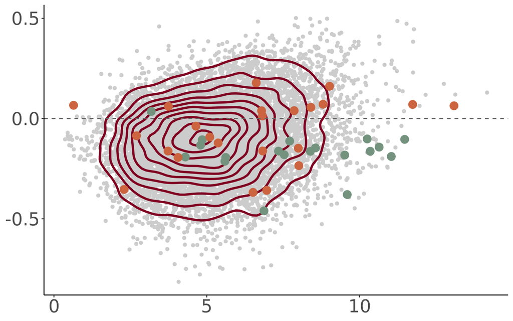

```r
# Publication-style version, stripped of axis titles, matching your "m" plot
(ma <- ggplot(data=DEGenes,
                 aes(x=AveExpr,
                     y=logFC)) +
  geom_point(color="#CCCCCC") + geom_density2d(color = "#800020", size = 1.2)+
  geom_point(data=MitoData, aes(x=AveExpr, y=logFC), color="#73937E", size=4) +
  geom_point(data=NucData, aes(x=AveExpr, y=logFC), color="#CB643F", size=4) +
  geom_hline(yintercept = 0, linetype="dashed", color="grey40") +
  ylab(expression(Log[2]~"Fold-Change")) +
  xlab("Average Expression (Log2 CPM)") +
  theme(
    axis.line = element_line(colour = "black"),
    panel.grid.major = element_blank(),
    panel.grid.minor = element_blank(),
    panel.border = element_blank(),
    panel.background = element_blank(),
    axis.title = element_blank()
  ) +
  theme(plot.title = element_text(hjust = 0.5), plot.subtitle = element_text(hjust = 0.5)) +
  theme(text=element_text(size=25, family="Arial MS")))
```

```r
png("~/Projects/StressGranules/SGPAPER/Images/PNG/CurdyMito_MA.png", width = 7, height=6, units = "in", res=300)
ma
dev.off()
```

## MA Plot

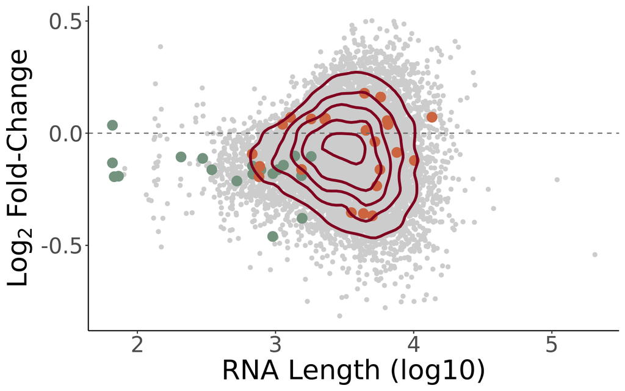

```r
MitoGenes <- fread("~/MitoGenes.txt")[[1]]

genelength <- read.csv("~/Projects/StressGranules/SG_Transcriptome/RP_Data_2021/TrimmedSamples/alignment_STAR/TranscriptLenght.txt", header=T)
genelength <- subset(genelength, Ensembl.Canonical==1)
genelength <- subset(genelength, Gene.name!="")
genelength <- genelength %>%
  group_by(Gene.name) %>%
  slice(which.max(Transcript.length..including.UTRs.and.CDS.)) %>%
  ungroup()
genelength <- genelength[,-c(2,3)]
colnames(genelength) <- c("Length", "Gene")

genelength$Cromo <- ifelse(genelength$Gene %in% MitoGenes, "Mito", "Other")

# Apply the length-based weight formula
genelength$S <- ifelse(
  genelength$Cromo == "Mito",
  (genelength$Length)^(1/3) * 3.23e-11 + 1.17e-9,   # Formula for mitochondrial RNAs
  (genelength$Length)^(1/3) * 6.09e-11 + 3.88e-10    # Formula for other RNAs
)
DEGenes$Gene <- row.names(DEGenes)
DEGenes <- merge(DEGenes, genelength, by="Gene")
MitoGenes <- fread("~/MitoGenes.txt")[[1]]
MitoData <- DEGenes[DEGenes$Gene %in% MitoGenes, ]
NucGenes <- fread("~/rnalocate_mito_filt.csv")[[1]]
NucData <- DEGenes[DEGenes$Gene %in% NucGenes, ]

# Publication-style version, stripped of axis titles, matching your "m" plot
(ma <- ggplot(data=DEGenes,
                 aes(x=log10(Length),
                     y=logFC)) +
  geom_point(color="#CCCCCC") +
  geom_point(data=MitoData, aes(x=log10(Length), y=logFC), color="#73937E", size=4) +
  geom_point(data=NucData, aes(x=log10(Length), y=logFC), color="#CB643F", size=4) +
  geom_hline(yintercept = 0, linetype="dashed", color="grey40") +
  ylab(expression(Log[2]~"Fold-Change")) +
  xlab("RNA Length (log10)") +geom_density2d(color = "#800020", size = 1.2)+
  theme(
    axis.line = element_line(colour = "black"),
    panel.grid.major = element_blank(),
    panel.grid.minor = element_blank(),
    panel.border = element_blank(),
    panel.background = element_blank()
  ) +
  theme(plot.title = element_text(hjust = 0.5), plot.subtitle = element_text(hjust = 0.5)) +
  theme(text=element_text(size=25, family="Arial MS")))
```

```r
png("~/Projects/StressGranules/SGPAPER/Images/PNG/CurdMito_MA_length.png", width = 7, height=6, units = "in", res=300)
ma
dev.off()
```

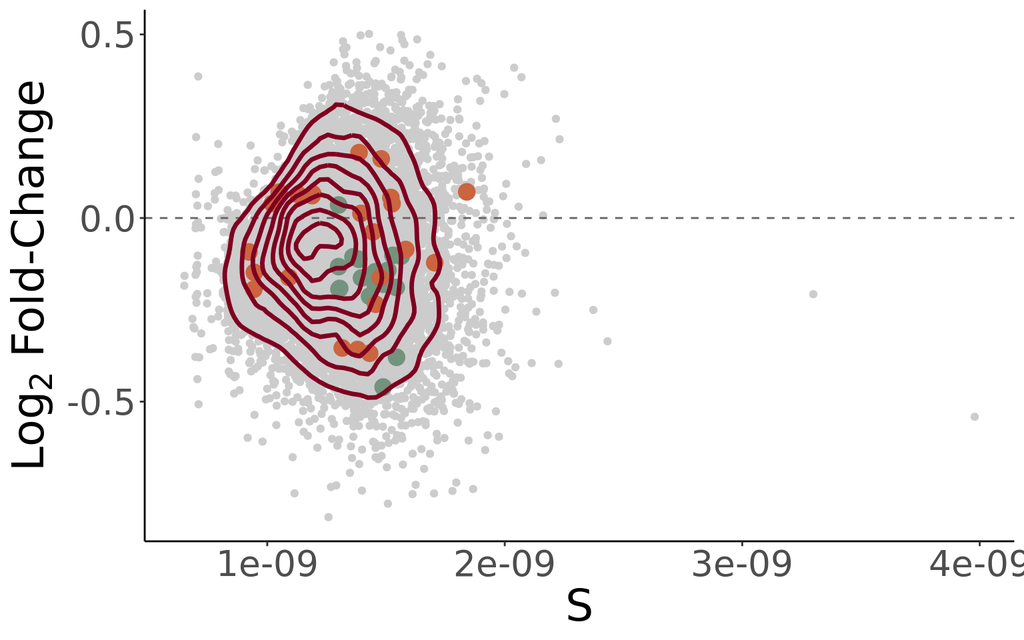

```r
# Publication-style version, stripped of axis titles, matching your "m" plot
(ma <- ggplot(data=DEGenes,
                 aes(x=(S),
                     y=logFC)) +
  geom_point(color="#CCCCCC") +
  geom_point(data=MitoData, aes(x=(S), y=logFC), color="#73937E", size=4) +
  geom_point(data=NucData, aes(x=(S), y=logFC), color="#CB643F", size=4) +
  geom_hline(yintercept = 0, linetype="dashed", color="grey40") +
  ylab(expression(Log[2]~"Fold-Change")) +geom_density2d(color = "#800020", size = 1.2)+
  xlab("S") +
  theme(
    axis.line = element_line(colour = "black"),
    panel.grid.major = element_blank(),
    panel.grid.minor = element_blank(),
    panel.border = element_blank(),
    panel.background = element_blank()
  ) +
  theme(plot.title = element_text(hjust = 0.5), plot.subtitle = element_text(hjust = 0.5)) +
  theme(text=element_text(size=25, family="Arial MS")))
```

```r
png("~/Projects/StressGranules/SGPAPER/Images/PNG/CurMito_MA_S.png", width = 7, height=6, units = "in", res=300)
ma
dev.off()
```

## Volcano Plot with Gene Length

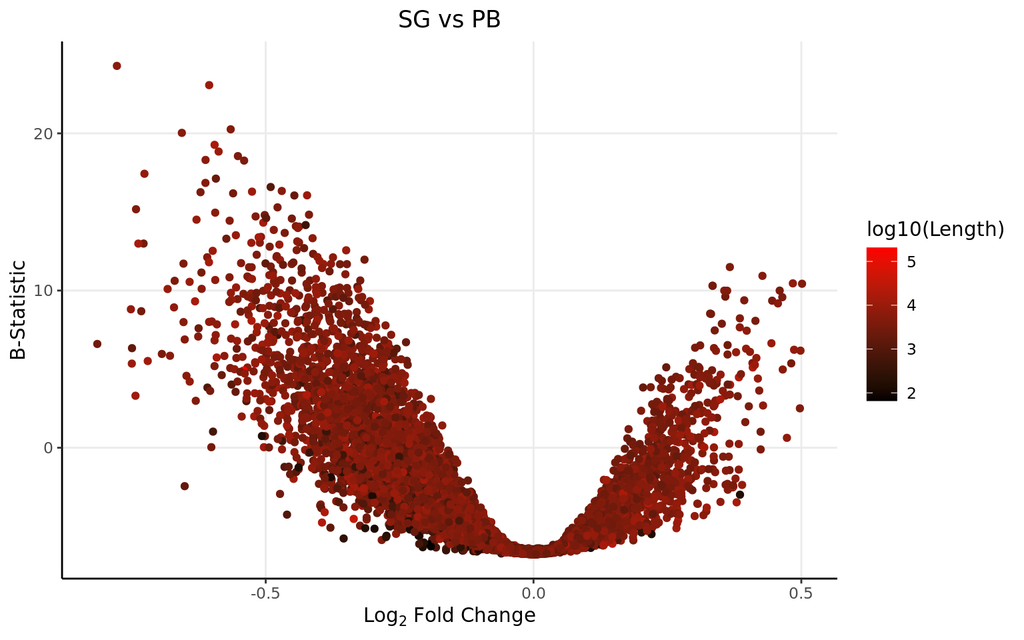

```r
DEGenes_SG.vs.PB$Gene <- row.names(DEGenes_SG.vs.PB)
DEGenes_SG.vs.PB <- merge(DEGenes_SG.vs.PB, genelength, by="Gene")

ggplot(data=DEGenes_SG.vs.PB,
                 aes(x=logFC,
                     y=  B)) +
  geom_point(aes(color=log10(Length)))+
  theme_bw() +
  theme(axis.line = element_line(colour = "black"),
        panel.grid.minor = element_blank(),
        panel.border = element_blank(),
        panel.background = element_blank()) +
  ggtitle("SG vs PB")+ xlab(expression(Log[2] ~ Fold ~ Change)) + ylab("B-Statistic") +
  theme(plot.title = element_text(hjust = 0.5))  +
  scale_colour_gradient(low = "black", high = "red")+ theme(text=element_text(family = "Quicksand"))
```

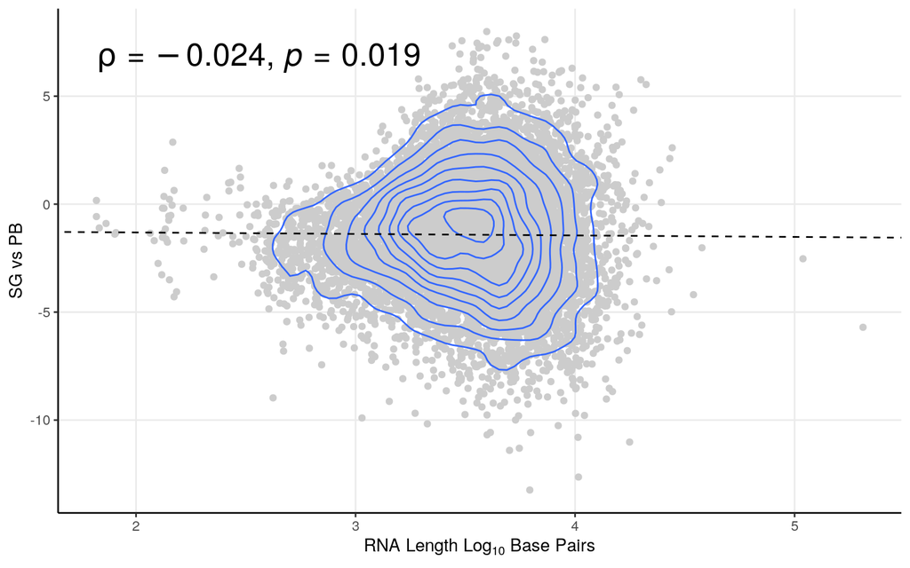

```r
smooth.SG <- lm(t~log10(Length), DEGenes_SG.vs.PB)
liner.SG <- rstandard(smooth.SG)
DEGenes_SG.vs.PB <-cbind(DEGenes_SG.vs.PB, liner.SG)
colnames(DEGenes_SG.vs.PB)[11] <- "Residuals"
row.names(DEGenes_SG.vs.PB) <- DEGenes_SG.vs.PB$Gene
linemarkers <- as.data.frame(DEGenes_SG.vs.PB[abs(DEGenes_SG.vs.PB$Residuals)>4,])

# Calculate the Spearman correlation coefficient
spearman_corr <- cor(DEGenes_SG.vs.PB$t, log10(DEGenes_SG.vs.PB$Length), method = "spearman")



ggplot(DEGenes_SG.vs.PB, aes(y=t, x=log10(Length))) + geom_point(color="#CCCCCC", alpha=1) +   theme_bw()+ geom_density_2d()+
 ylab("SG vs PB") + xlab(expression(RNA ~ Length ~ Log[10] ~ Base ~ Pairs)) +
  theme(axis.line = element_line(colour = "black"),
        panel.grid.minor = element_blank(),
        panel.border = element_blank(),
        panel.background = element_blank()) +
  theme(plot.title = element_text(hjust = 0.5))  +
  geom_abline(slope=smooth.SG$coefficients[2], intercept = smooth.SG$coefficients[1], linetype = "dashed")+ stat_cor(method = "spearman", cor.coef.name = "rho",size=7)
```

## Expression Graphs (Extra QC)

As an added control, lets plot these genes in regard to their expression. This helps to see if the expression differences are robust, and not just driven by one sample.

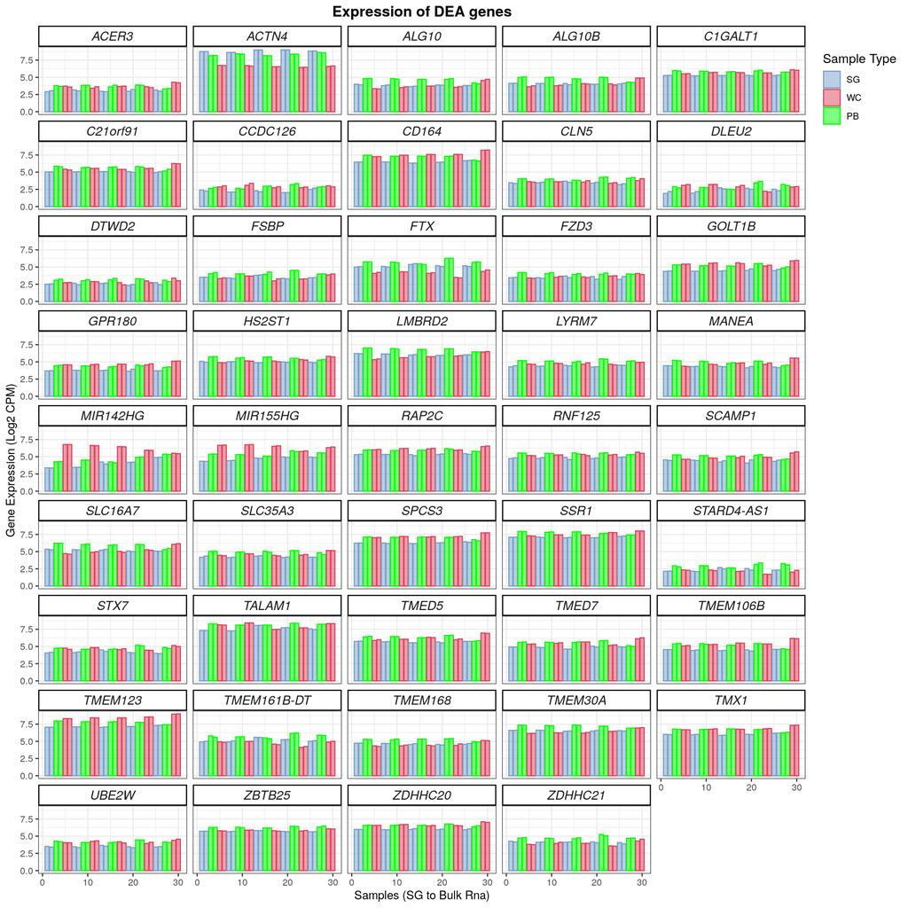

```r
upmarkers <- as.data.frame(DEGenes_SG.vs.PB[DEGenes_SG.vs.PB$logFC>0.5 & DEGenes_SG.vs.PB$adj.P.Val<0.05,] )
downmarkers <- as.data.frame(DEGenes_SG.vs.PB[DEGenes_SG.vs.PB$logFC< -0.6 & DEGenes_SG.vs.PB$adj.P.Val<0.05,] )

finagenes <- rbind(upmarkers, downmarkers)

dfforexpression <- dfforpca
samplecodes <- data.frame(samples=row.names(dfforexpression), purity=c(1:30))
sampletype <- data.frame(samples=row.names(dfforexpression), sampletype=forsimple)
dfforexpression <- t(dfforexpression)
genesforexp <- dfforexpression[row.names(dfforexpression)%in%row.names(finagenes),]
genesforexp <- reshape2::melt(genesforexp)
colnames(genesforexp) <- c("Gene", "samples", "expression")
genesforexp <- merge(genesforexp, samplecodes, by="samples")
genesforexp <- merge(genesforexp, sampletype, by="samples")
genesforexp <- genesforexp[,-1]
genesforexp[,2] <- as.numeric(genesforexp[,2])
genesforexp[,1] <- as.character(genesforexp[,1])
genesforexp <- genesforexp[order(genesforexp$Gene),]


winnyplot <- ggplot(genesforexp, aes(x=purity, y=expression, fill=sampletype, colour=sampletype)) + geom_bar(position="dodge", stat="identity", alpha=0.5) + facet_wrap(.~ Gene, ncol=5)
winnyplot <- winnyplot + scale_fill_manual(name = "Sample Type", values = c("#769fca", "#de425b", "green"), breaks = c("SG", "WC", "PB")) + scale_colour_manual(name = "Sample Type", values = c("#769fca", "#de425b", "green"), breaks = c("SG", "WC", "PB"))
winnyplot <- winnyplot + theme_bw() + xlab("Samples (SG to Bulk Rna)") + ylab("Gene Expression (Log2 CPM)") + theme(
      strip.text.x = element_text(
        size = 12, face="italic"
        )) +
 theme(
   strip.background = element_rect(
     color="black", fill="#FFFFFF", size=1, linetype="solid"
     )
   ) + theme(
    #legend.position = c(.95, .40),
    legend.justification = c("right", "top"),
    legend.box.just = "right",
    ) + theme(legend.title = element_text(size = 12)) + ggtitle("Expression of DEA genes") + theme(plot.title = element_text(hjust = 0.5, size=14, face="bold"))
winnyplot
```

```r
## Signature Violin (Mito/Nuc) - SG vs PB

library(data.table)
library(dplyr)
library(ggplot2)
library(rstatix)
# Restrict to just the SG and PB samples used in DEGenes_SG.vs.PB (exclude WC)
sgpb_idx <- which(forsimple %in% c("SG", "PB"))

expression.df <- y$E[, sgpb_idx]
cond <- factor(forsimple[sgpb_idx], levels = c("PB", "SG"))

custom_palette <- c(
  "PB" = "#399e5a",
  "SG" = "#769fca"
)

# ── 1. Gene sets already loaded earlier in the script (MitoGenes, NucGenes) ──
mito_genes_present <- MitoGenes[MitoGenes %in% rownames(expression.df)]
nuc_genes_present  <- NucGenes[NucGenes %in% rownames(expression.df)]
cat(length(mito_genes_present), "Mito genes found in expression matrix\n")
```

```
## 19 Mito genes found in expression matrix
```

```r
cat(length(nuc_genes_present), "Nuc genes found in expression matrix\n")
```

```
## 23 Nuc genes found in expression matrix
```

```r
# ── 2. Rank all genes per sample (1 = least expressed) ───────────────────────
rank_matrix <- apply(expression.df, 2, function(x) rank(x, ties.method = "average"))
rank_matrix <- as.data.frame(rank_matrix)

# ── 3. Compute a rank-sum score per sample, one gene set at a time ───────────
compute_score <- function(genes, rank_matrix, n_total) {
  colSums(rank_matrix[genes, , drop = FALSE]) / n_total
}

mito_score <- compute_score(mito_genes_present, rank_matrix, nrow(expression.df))
nuc_score  <- compute_score(nuc_genes_present, rank_matrix, nrow(expression.df))

# ── 4. Assemble plot dataframe, long format across both gene sets ────────────
score_df <- rbind(
  data.frame(Sample = colnames(expression.df), Score = as.numeric(mito_score),
             Condition = cond, GeneSet = "Mito"),
  data.frame(Sample = colnames(expression.df), Score = as.numeric(nuc_score),
             Condition = cond, GeneSet = "Nuc")
)

# ── 5. Statistics per gene set: one-way ANOVA (equivalent to t-test, 2 groups) ──
stat_labels <- score_df %>%
  group_by(GeneSet) %>%
  group_modify(~{
    aov_res  <- aov(Score ~ Condition, data = .x)
    aov_tidy <- summary(aov_res)
    p_raw  <- aov_tidy[[1]][["Pr(>F)"]][1]
    p_adj  <- p.adjust(p_raw, method = "BH")
    ss_between <- aov_tidy[[1]][["Sum Sq"]][1]
    ss_total   <- sum(aov_tidy[[1]][["Sum Sq"]])
    eta_sq     <- ss_between / ss_total
    cohens_f   <- sqrt(eta_sq / (1 - eta_sq))
    data.frame(
      label = paste0("Cohen's f = ", round(cohens_f, 3),
                      "\nadj. p = ", formatC(p_adj, format = "e", digits = 2))
    )
  })

# ── 6. Plot ───────────────────────────────────────────────────────────────────
vilsigplot <- ggplot(score_df, aes(x = Condition, y = Score, fill = Condition)) +
  geom_violin(colour = "black", alpha = 0.6, trim = FALSE) +
  geom_point(
    position = position_jitter(width = 0.1),
    alpha    = 0.7,
    size     = 1.5
  ) +
  stat_summary(fun = mean,   geom = "point", shape = 18,
               size = 3, colour = "black") +
  stat_summary(fun = median, geom = "point", shape = 17,
               size = 3, colour = "black") +
  geom_text(
    data  = stat_labels,
    aes(x = -Inf, y = Inf, label = label),
    hjust = -0.05, vjust = 1.2,
    size  = 4, fontface = "bold", lineheight = 1.1,
    inherit.aes = FALSE
  ) +
  facet_wrap(~GeneSet, scales = "free_y") +
  scale_fill_manual(values = custom_palette) +
  labs(
    x     = "Fraction",
    y     = "Signature Score (Rank Sum)",
    title = "Mitochondrial vs Nuclear-Localized Gene Scores - SG vs PB"
  ) +
  theme_bw() +
  theme(
    plot.title      = element_text(hjust = 0.5, size = 14, face = "bold"),
    axis.text.x     = element_text(size = 12),
    strip.text      = element_text(size = 12, face = "bold"),
    legend.position = "none"
  )

png("~/Projects/StressGranules/SGPAPER/Images/PNG/CurdySGvsPB_MitoSigs.png", width = 14, height=6, units = "in", res=300)
vilsigplot
dev.off()
```

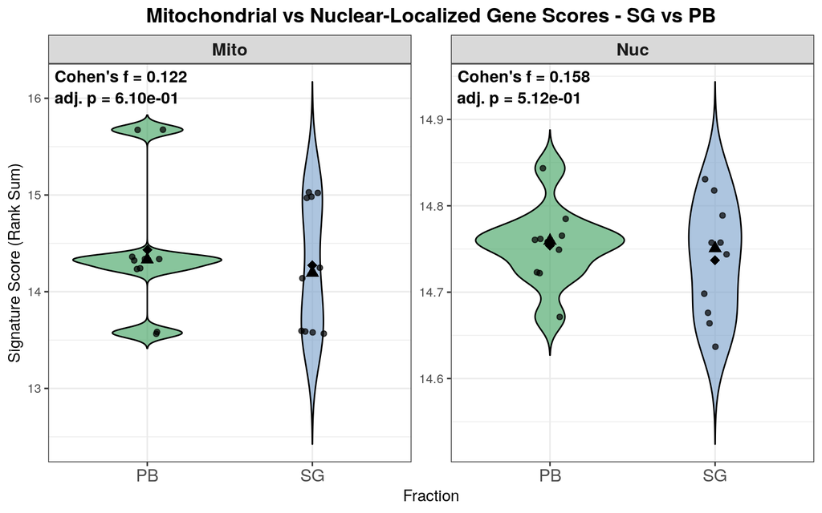

```r
vilsigplot
```

## GSEA Enrichment

Now that we have our genes of interest, it would also be interesting to see what are the **altered gene sets** between upregulated and downregulated transcripts from the above comparison. Therefore, lets perform a *Gene Set Enrichment Analysis*

```r
#for all genes
DEGenes_SG.vs.PB <- DEGenes_SG.vs.PB[order(DEGenes_SG.vs.PB[,4]),]
gseatool <- DEGenes_SG.vs.PB[,4]
gseatool <- as.data.frame(gseatool)
colnames(gseatool)[1] <- "t"
gseatool[,2] <- DEGenes_SG.vs.PB$Gene
colnames(gseatool)[2] <- "Symbol"
gseatool <- gseatool[,c(2,1)]

vectorranks <- gseatool$t
names(vectorranks) <- gseatool$Symbol


#to load our pathways
hallmarks.gs <- msigdbr(species = "Homo sapiens", collection =  "H")

hallmarks.gsets <- hallmarks.gs %>% split(x = .$gene_symbol, f = .$gs_name)

for (set in names(hallmarks.gsets)){
  hallmarks.gsets[[set]] <- toupper(hallmarks.gsets[[set]])
}

hallmarks.res <- fgsea(pathways = hallmarks.gsets,
                       stats = vectorranks)
```

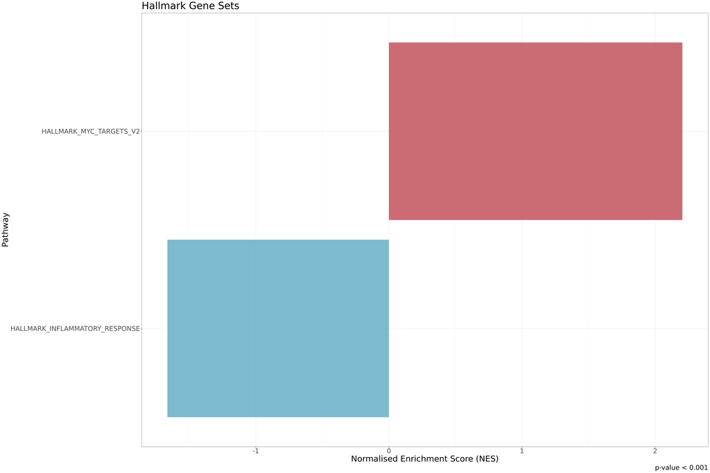

```r
hallmarks.res.tidy <- hallmarks.res %>%
  as_tibble() %>%
  arrange(desc(NES))

hallmarks.res.tidy %>%
  dplyr::select(-leadingEdge, -ES) %>%
  arrange(padj)

hallmark.sg.t <- hallmarks.res.tidy[,c(1,3,6)]
hallmark.sg.t <- as.data.frame(hallmark.sg.t)

#this small part is generic
thresh <- 0.001

#this one is no longer generic
data_to_plot <- hallmarks.res.tidy %>% filter(padj < thresh)

statvec <- c()
for (i in 1:nrow(data_to_plot)){
  if (data_to_plot[i,6] > 0){
    status <- "Upregulated"
  }
 else {
   status <- "Downregulated"
 }
statvec <- c(statvec, status)
}

data_to_plot$Status <- statvec

##-----HALMARK-----
gsea_plot_hall <- ggplot(data_to_plot, aes(reorder(pathway, NES), NES)) +
  geom_col(aes(fill= Status), alpha=0.75) + scale_fill_manual(values = c("#53A2BE","#BA3B46"), name = "Regulation Status", labels = c("Downregulated", "Upregulated"), breaks = c("Downregulated", "Upregulated")) +
  coord_flip() +
  labs(x="Pathway", y="Normalised Enrichment Score (NES)",
       title= "Hallmark Gene Sets",
       caption = paste0("p-value < ", thresh)) + theme(plot.title = element_text(hjust = 1)) +
  theme_bw() + theme(text=element_text(family = "Quicksand")) + theme(legend.position = "none")


gsea_plot_hall+
  theme(text=element_text(size=25,  family="Arial MS"))
```

### For Mito

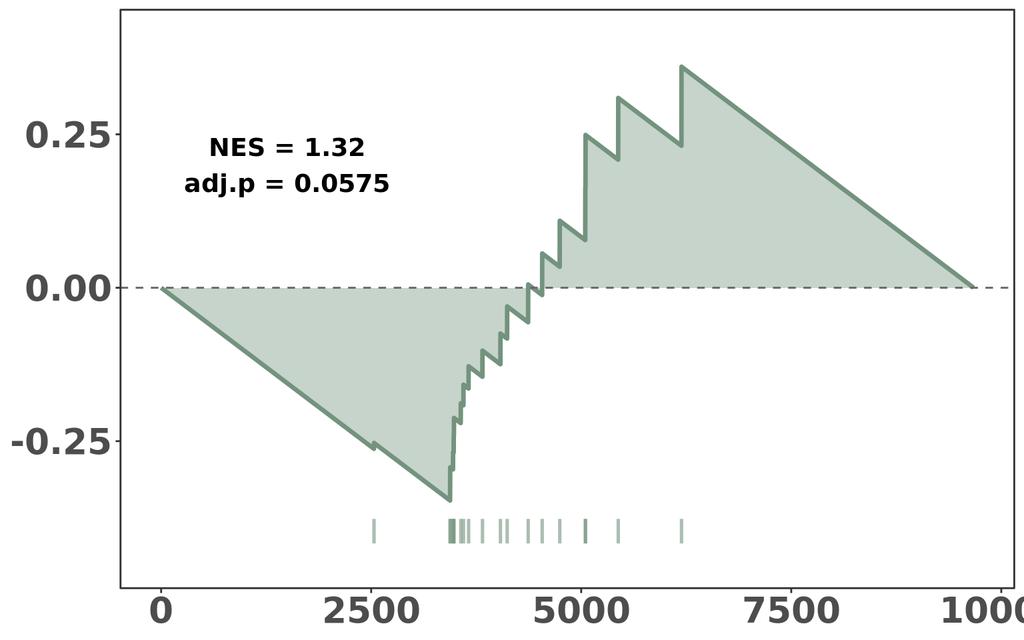

```r
# --- Rank genes by t-statistic as usual ---
DEGenes_SG.vs.PB <- DEGenes_SG.vs.PB[order(DEGenes_SG.vs.PB[,4]),]
gseatool <- DEGenes_SG.vs.PB[,4]
gseatool <- as.data.frame(gseatool)
colnames(gseatool)[1] <- "t"
gseatool[,2] <- row.names(DEGenes_SG.vs.PB)
colnames(gseatool)[2] <- "Symbol"
gseatool <- gseatool[,c(2,1)]
vectorranks <- gseatool$t
names(vectorranks) <- gseatool$Symbol

# --- Define MitoGenes as a custom gene set ---
MitoGenes <- fread("~/MitoGenes.txt")[[1]]
custom.gsets <- list(MitoGenes = toupper(MitoGenes))

# --- Run fgsea ---
mito.res <- fgsea(pathways = custom.gsets,
                  stats = vectorranks)

mito.plot.base <- plotEnrichment(custom.gsets[["MitoGenes"]], vectorranks)
curve.data <- mito.plot.base$data

# --- key fix: match the curve's internal descending order ---
ord <- order(vectorranks, decreasing = TRUE)
ranked.names <- names(vectorranks)[ord]
gene.positions <- which(ranked.names %in% custom.gsets[["MitoGenes"]])

rug.top    <- min(curve.data$y) - 0.03
rug.bottom <- rug.top - 0.04

y.min <- rug.bottom - 0.03
y.max <- max(curve.data$y) + 0.05

(mito.plot <- ggplot(curve.data, aes(x = x, y = y)) +
  geom_area(fill = "#73937E", alpha = 0.4) +
  geom_line(color = "#73937E", linewidth = 1.2) +
  geom_hline(yintercept = 0, linetype = "dashed", color = "grey40") +
  geom_segment(data = data.frame(x = gene.positions),
               aes(x = x, xend = x, y = rug.top, yend = rug.bottom),
               color = "#73937E", alpha = 0.6, linewidth = 0.9,
               inherit.aes = FALSE) +
  annotate("text", x = 1500, y = 0.2,
           label = paste0("NES = ", round(mito.res$NES, 2),
                          "\nadj.p = ", round(mito.res$padj, 4)),
           size = 5, family = "Arial MS", fontface = "bold") +
  coord_cartesian(ylim = c(y.min, y.max), clip = "off") +
  theme_bw() +
  theme(text = element_text(size = 25, family = "Arial MS"),
        plot.title = element_text(hjust = 0.5, face = "bold"),
        axis.title = element_blank(),
        axis.text = element_text(face = "bold"),
        panel.grid.minor = element_blank(),
        panel.grid.major = element_blank()))
```

```r
png("~/Projects/StressGranules/SGPAPER/Images/PNG/MitoGSEA_Curdy.png", width=7, height=6, units="in", res=300)
mito.plot
dev.off()
```